# Tugas Pertemuan 1

```r
library("forecast")
library("graphics")
library("TTR")
library("TSA")
```

## Impor Data

```r
library(rio)
data2 <- import("C:\\Users\\62878\\OneDrive\\Gambar\\MPDW\\data suhu bogor 500 akhir.xlsx")

head(data2)
```

```
##         time temperature_2m_mean (°C)
## 1 2025-04-14                     26.0
## 2 2025-04-15                     24.9
## 3 2025-04-16                     26.2
## 4 2025-04-17                     25.6
## 5 2025-04-18                     26.1
## 6 2025-04-19                     25.7
```

```r
data1 <- data2[301:400, ]
head(data1)
```

```
##           time temperature_2m_mean (°C)
## 301 2026-02-08                     25.1
## 302 2026-02-09                     24.1
## 303 2026-02-10                     24.3
## 304 2026-02-11                     25.1
## 305 2026-02-12                     24.7
## 306 2026-02-13                     24.7
```

## Eksplorasi Data

```r
View(data1)
str(data1)
```

```
## 'data.frame':    100 obs. of  2 variables:
##  $ time                    : POSIXct, format: "2026-02-08" "2026-02-09" ...
##  $ temperature_2m_mean (°C): num  25.1 24.1 24.3 25.1 24.7 24.7 25.3 25.3 24.5 25.8 ...
```

```r
dim(data1)
```

```
## [1] 100   2
```

Mengubah data agar terbaca sebagai data deret waktu dengan fungsi `ts()` .

```r
data1.ts <- ts(data1[,2])
```

Menampilkan ringkasan data

```r
summary(data1.ts)
```

```
##    Min. 1st Qu.  Median    Mean 3rd Qu.    Max.
##   23.60   25.30   26.10   26.03   26.80   27.90
```

Membuat plot data deret waktu

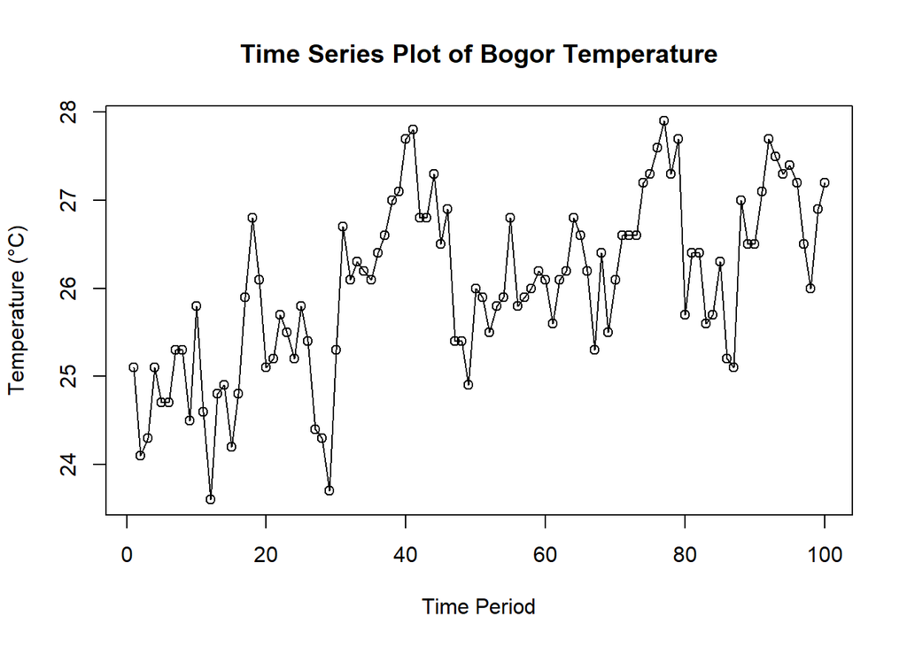

```r
ts.plot(data1.ts,
        xlab = "Time Period",
        ylab = "Temperature (°C)",
        main = "Time Series Plot of Bogor Temperature")

points(data1.ts)
```

```r
# menyimpan plot
dev.copy(png, "plot_data1.png")
```

```r
dev.off()
```

## Moving Average

### Pembagian Data

```r
# hitung jumlah data
n <- nrow(data1)

# tentukan batas 80%
n_train <- floor(0.8 * n)

# bagi data
training_ma <- data1[1:n_train, ]
testing_ma  <- data1[(n_train+1):n, ]

# ubah ke time series
train_ma.ts <- ts(training_ma[,2])
test_ma.ts  <- ts(testing_ma[,2])
```

Eksplorasi data dilakukan pada keseluruhan data, data latih serta data uji menggunakan plot data deret waktu.

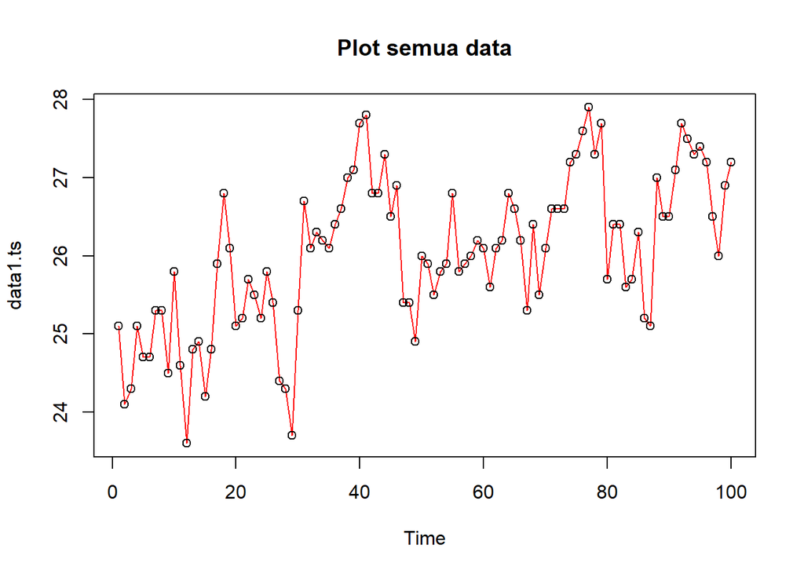

```r
# eksplorasi keseluruhan data
plot(data1.ts, col="red", main="Plot semua data")
points(data1.ts)
```

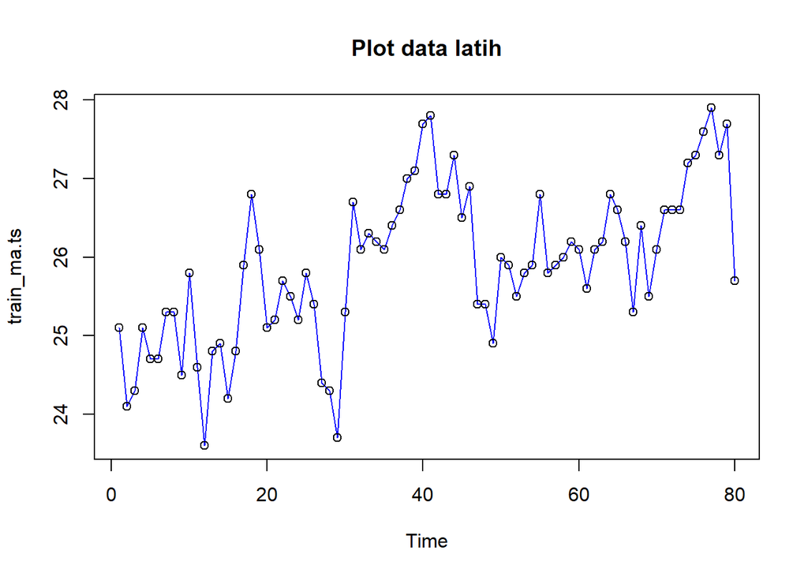

```r
# eksplorasi data latih
plot(train_ma.ts, col="blue", main="Plot data latih")
points(train_ma.ts)
```

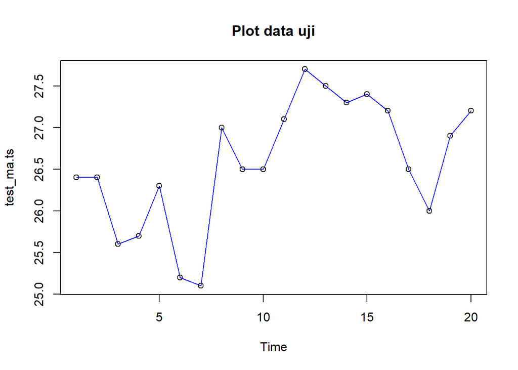

```r
# eksplorasi data uji
plot(test_ma.ts, col="blue", main="Plot data uji")
points(test_ma.ts)
```

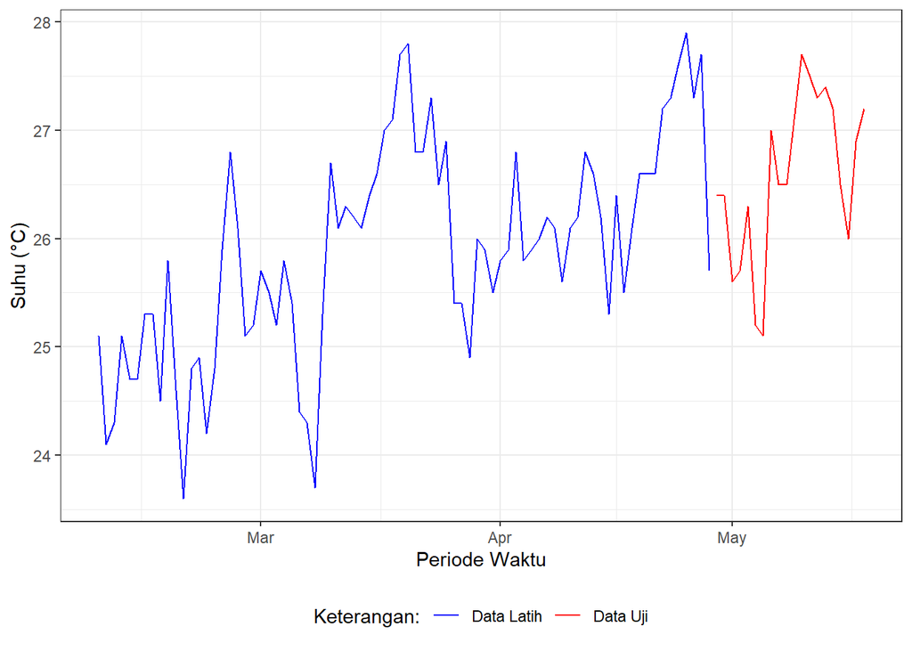

```r
library(ggplot2)

ggplot() +
  geom_line(data = training_ma,
            aes(x = time, y = `temperature_2m_mean (°C)`, col = "Data Latih")) +
  geom_line(data = testing_ma,
            aes(x = time, y = `temperature_2m_mean (°C)`, col = "Data Uji")) +
  labs(x = "Periode Waktu",
       y = "Suhu (°C)",
       color = "Legend") +
  scale_colour_manual(
    name = "Keterangan:",
    breaks = c("Data Latih", "Data Uji"),
    values = c("blue", "red")
  ) +
  theme_bw() +
  theme(
    legend.position = "bottom",
    plot.caption = element_text(hjust = 0.5, size = 12)
  )
```

### Single Moving Average (SMA)

```r
data.sma<-SMA(train_ma.ts, n=4)
data.sma
```

```
## Time Series:
## Start = 1
## End = 80
## Frequency = 1
##  [1]     NA     NA     NA 24.650 24.550 24.700 24.950 25.000 24.950 25.225
## [11] 25.050 24.625 24.700 24.475 24.375 24.675 24.950 25.425 25.900 25.975
## [21] 25.800 25.525 25.375 25.400 25.550 25.475 25.200 24.975 24.450 24.425
## [31] 25.000 25.450 26.100 26.325 26.175 26.250 26.325 26.525 26.775 27.100
## [41] 27.400 27.350 27.275 27.175 26.850 26.875 26.525 26.050 25.650 25.425
## [51] 25.550 25.575 25.800 25.775 26.000 26.075 26.100 26.125 25.975 26.050
## [61] 25.975 26.000 26.000 26.175 26.425 26.450 26.225 26.125 25.850 25.825
## [71] 26.150 26.200 26.475 26.750 26.925 27.175 27.500 27.525 27.625 27.150
```

Data pemulusan pada periode ke-t selanjutnya digunakan sebagai nilai peramalan pada periode ke t+1 sehingga hasil peramalan 1 periode kedepan adalah sebagai berikut.

```r
data.ramal<-c(NA,data.sma)
data.ramal
```

```
##  [1]     NA     NA     NA     NA 24.650 24.550 24.700 24.950 25.000 24.950
## [11] 25.225 25.050 24.625 24.700 24.475 24.375 24.675 24.950 25.425 25.900
## [21] 25.975 25.800 25.525 25.375 25.400 25.550 25.475 25.200 24.975 24.450
## [31] 24.425 25.000 25.450 26.100 26.325 26.175 26.250 26.325 26.525 26.775
## [41] 27.100 27.400 27.350 27.275 27.175 26.850 26.875 26.525 26.050 25.650
## [51] 25.425 25.550 25.575 25.800 25.775 26.000 26.075 26.100 26.125 25.975
## [61] 26.050 25.975 26.000 26.000 26.175 26.425 26.450 26.225 26.125 25.850
## [71] 25.825 26.150 26.200 26.475 26.750 26.925 27.175 27.500 27.525 27.625
## [81] 27.150
```

```r
data.gab <- cbind(
  aktual = c(data1.ts),
  pemulusan = c(data.sma, rep(NA, 20)),
  ramalan = c(data.ramal, rep(data.ramal[length(data.ramal)], 19))
)

data.gab
```

```
##        aktual pemulusan ramalan
##   [1,]   25.1        NA      NA
##   [2,]   24.1        NA      NA
##   [3,]   24.3        NA      NA
##   [4,]   25.1    24.650      NA
##   [5,]   24.7    24.550  24.650
##   [6,]   24.7    24.700  24.550
##   [7,]   25.3    24.950  24.700
##   [8,]   25.3    25.000  24.950
##   [9,]   24.5    24.950  25.000
##  [10,]   25.8    25.225  24.950
##  [11,]   24.6    25.050  25.225
##  [12,]   23.6    24.625  25.050
##  [13,]   24.8    24.700  24.625
##  [14,]   24.9    24.475  24.700
```

[output cut: 86 more lines]

Adapun plot data deret waktu dari hasil peramalan yang dilakukan adalah sebagai berikut.

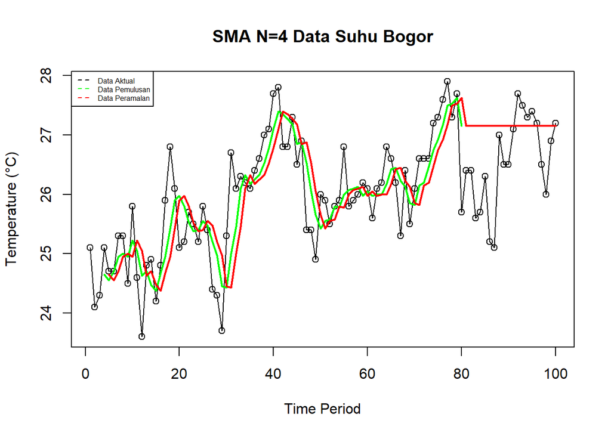

```r
ts.plot(data1.ts,
        xlab = "Time Period",
        ylab = "Temperature (°C)",
        main = "SMA N=4 Data Suhu Bogor")

points(data1.ts)

lines(data.gab[,2], col = "green", lwd = 2)
lines(data.gab[,3], col = "red", lwd = 2)

legend("topleft",
       c("Data Aktual", "Data Pemulusan", "Data Peramalan"),
       lty = 8,
       col = c("black", "green", "red"),
       cex = 0.5)
```

#### Akurasi Data Latih

```r
#Menghitung nilai keakuratan data latih
error_train.sma = train_ma.ts - data.ramal[1:length(train_ma.ts)]

SSE_train.sma = sum(error_train.sma[5:length(train_ma.ts)]^2)
MSE_train.sma = mean(error_train.sma[5:length(train_ma.ts)]^2)
MAPE_train.sma = mean(abs((error_train.sma[5:length(train_ma.ts)] /
                            train_ma.ts[5:length(train_ma.ts)]) * 100))

akurasi_train.sma <- matrix(c(SSE_train.sma,
                              MSE_train.sma,
                              MAPE_train.sma))

row.names(akurasi_train.sma) <- c("SSE", "MSE", "MAPE")
colnames(akurasi_train.sma) <- c("Akurasi m = 4")

akurasi_train.sma
```

```
##      Akurasi m = 4
## SSE     41.8637500
## MSE      0.5508388
## MAPE     2.2135734
```

### Akurasi Data Uji

```r
# Menghitung nilai keakuratan data uji
error_test.sma = test_ma.ts - data.gab[81:100,3]

SSE_test.sma = sum(error_test.sma^2)
MSE_test.sma = mean(error_test.sma^2)
MAPE_test.sma = mean(abs((error_test.sma/test_ma.ts)*100))

akurasi_test.sma <- matrix(c(SSE_test.sma,
                             MSE_test.sma,
                             MAPE_test.sma))

row.names(akurasi_test.sma) <- c("SSE", "MSE", "MAPE")
colnames(akurasi_test.sma) <- c("Akurasi m = 4")

akurasi_test.sma
```

```
##      Akurasi m = 4
## SSE      17.550000
## MSE       0.877500
## MAPE      2.752734
```

Perhitungan akurasi menggunakan data uji menghasilkan nilai MAPE yang kurang dari 10% sehingga nilai akurasi ini dapat dikategorikan sebagai sangat baik.

### Double Moving Average (DMA)

```r
dma <- SMA(data.sma, n = 4)

At <- 2 * data.sma - dma
Bt <- 2/(4-1) * (data.sma - dma)

data.dma <- At + Bt
data.ramal2 <- c(NA, data.dma)

t = 1:20
f = c()

for (i in t) {
  f[i] = At[length(At)] + Bt[length(Bt)] * i
}

data.gab2 <- cbind(
  aktual = c(data1.ts),
  pemulusan1 = c(data.sma, rep(NA, 20)),
  pemulusan2 = c(dma, rep(NA, 20)),
  At = c(At, rep(NA, 20)),
  Bt = c(Bt, rep(NA, 20)),
  ramalan = c(data.ramal2, f[-1])
)

data.gab2
```

```
##        aktual pemulusan1 pemulusan2       At            Bt  ramalan
##   [1,]   25.1         NA         NA       NA            NA       NA
##   [2,]   24.1         NA         NA       NA            NA       NA
##   [3,]   24.3         NA         NA       NA            NA       NA
##   [4,]   25.1     24.650         NA       NA            NA       NA
##   [5,]   24.7     24.550         NA       NA            NA       NA
##   [6,]   24.7     24.700         NA       NA            NA       NA
##   [7,]   25.3     24.950   24.71250 25.18750  1.583333e-01       NA
##   [8,]   25.3     25.000   24.80000 25.20000  1.333333e-01 25.34583
##   [9,]   24.5     24.950   24.90000 25.00000  3.333333e-02 25.33333
##  [10,]   25.8     25.225   25.03125 25.41875  1.291667e-01 25.03333
##  [11,]   24.6     25.050   25.05625 25.04375 -4.166667e-03 25.54792
##  [12,]   23.6     24.625   24.96250 24.28750 -2.250000e-01 25.03958
##  [13,]   24.8     24.700   24.90000 24.50000 -1.333333e-01 24.06250
##  [14,]   24.9     24.475   24.71250 24.23750 -1.583333e-01 24.36667
```

[output cut: 86 more lines]

Hasil pemulusan menggunakan metode DMA divisualisasikan sebagai berikut

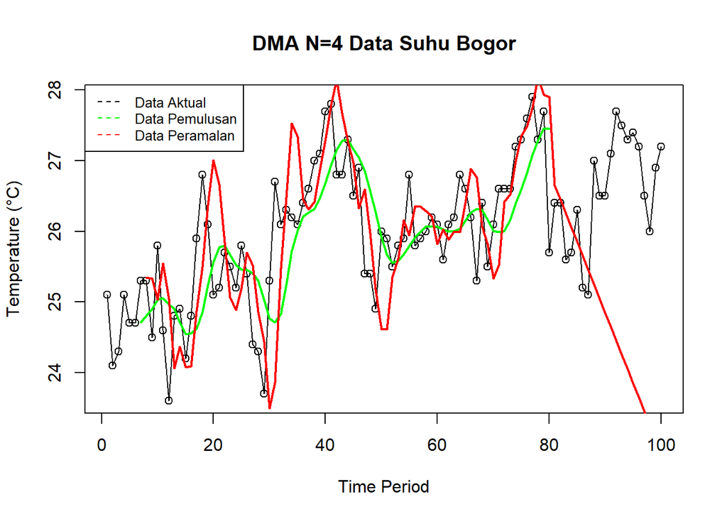

```r
ts.plot(data1.ts,
        xlab = "Time Period",
        ylab = "Temperature (°C)",
        main = "DMA N=4 Data Suhu Bogor")

points(data1.ts)

lines(data.gab2[,3], col = "green", lwd = 2)
lines(data.gab2[,6], col = "red", lwd = 2)

legend("topleft",
       c("Data Aktual", "Data Pemulusan", "Data Peramalan"),
       lty = 8,
       col = c("black", "green", "red"),
       cex = 0.8)
```

Selanjutnya perhitungan akurasi dilakukan baik pada data latih maupun data uji. Perhitungan akurasi dilakukan dengan ukuran akurasi SSE, MSE dan MAPE.

#### Akurasi Data Latih

```r
# Menghitung nilai keakuratan data latih
error_train.dma = train_ma.ts - data.ramal2[1:length(train_ma.ts)]

SSE_train.dma = sum(error_train.dma[8:length(train_ma.ts)]^2)
MSE_train.dma = mean(error_train.dma[8:length(train_ma.ts)]^2)
MAPE_train.dma = mean(abs((error_train.dma[8:length(train_ma.ts)] /
                            train_ma.ts[8:length(train_ma.ts)]) * 100))

akurasi_train.dma <- matrix(c(SSE_train.dma,
                              MSE_train.dma,
                              MAPE_train.dma))

row.names(akurasi_train.dma) <- c("SSE", "MSE", "MAPE")
colnames(akurasi_train.dma) <- c("Akurasi m = 4")

akurasi_train.dma
```

```
##      Akurasi m = 4
## SSE     54.1539887
## MSE      0.7418355
## MAPE     2.5246477
```

Perhitungan akurasi pada data latih menggunakan nilai MAPE menghasilkan nilai MAPE yang kurang dari 10% sehingga dikategorikan sangat baik. Selanjutnya, perhitungan nilai akurasi dilakukan pada data uji.

#### Akurasi Data Uji

```r
# Menghitung nilai keakuratan data uji
error_test.dma = test_ma.ts - data.gab2[81:100,6]

SSE_test.dma = sum(error_test.dma^2)
MSE_test.dma = mean(error_test.dma^2)
MAPE_test.dma = mean(abs((error_test.dma/test_ma.ts)*100))

akurasi_test.dma <- matrix(c(SSE_test.dma, MSE_test.dma, MAPE_test.dma))

row.names(akurasi_test.dma) <- c("SSE", "MSE", "MAPE")
colnames(akurasi_test.dma) <- c("Akurasi m = 4")

akurasi_test.dma
```

```
##      Akurasi m = 4
## SSE     122.530000
## MSE       6.126500
## MAPE      7.550169
```

Pada data latih, metode SMA lebih baik dibandingkan dengan metode DMA, dan pada data uji, metode SMA juga lebih baik dibandingkan dengan metode DMA.

## Exponential Smoothing

### Pembagian Data

```r
# jumlah baris data
n <- nrow(data1)

# hitung batas 80%
n_train <- floor(0.8 * n)

# bagi data
training <- data1[1:n_train, ]
testing  <- data1[(n_train+1):n, ]

# ubah ke time series
train.ts <- ts(training[,2])
test.ts  <- ts(testing[,2])
```

### Eksplorasi

Eksplorasi dilakukan dengan membuat plot data deret waktu untuk keseluruhan data, data latih, dan data uji.

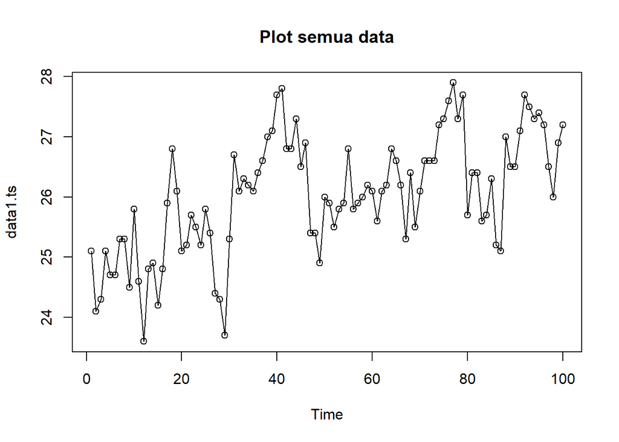

```r
#eksplorasi data
plot(data1.ts, col="black",main="Plot semua data")
points(data1.ts)
```

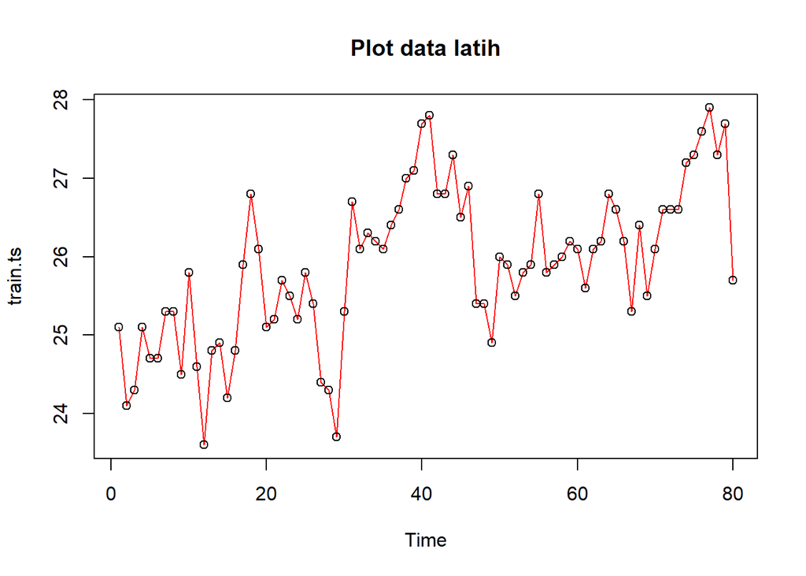

```r
plot(train.ts, col="red",main="Plot data latih")
points(train.ts)
```

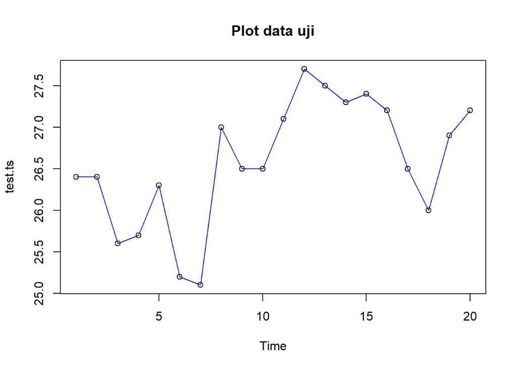

```r
plot(test.ts, col="blue",main="Plot data uji")
points(test.ts)
```

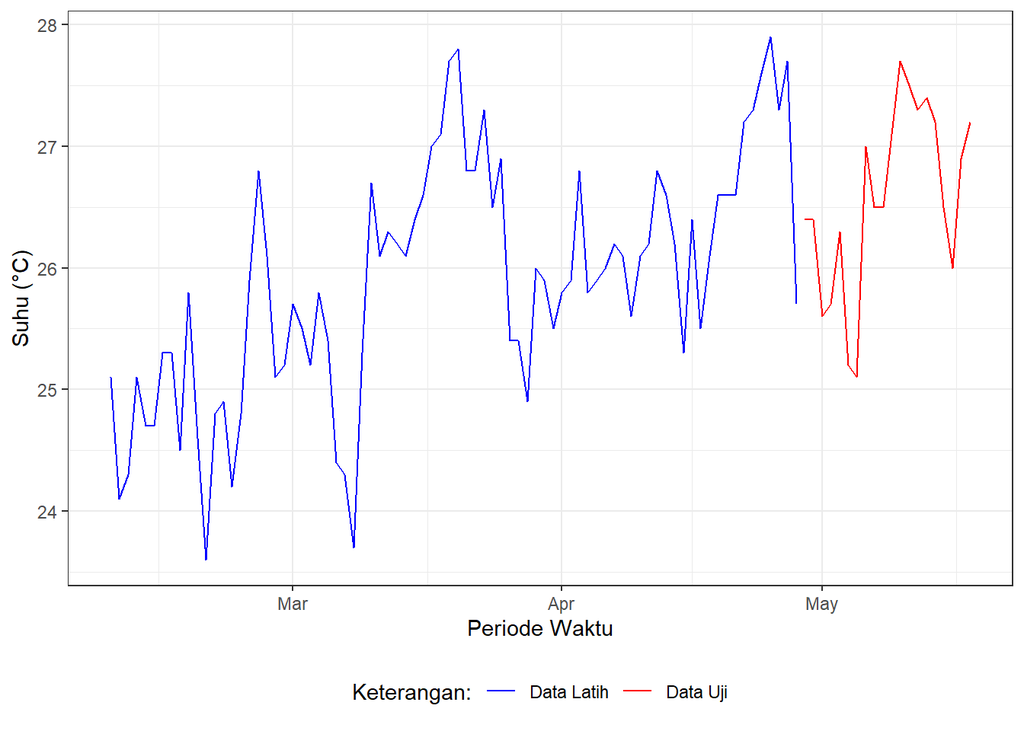

```r
# Eksplorasi dengan GGPLOT
library(ggplot2)

ggplot() +
  geom_line(data = training,
            aes(x = time, y = `temperature_2m_mean (°C)`,
                col = "Data Latih")) +
  geom_line(data = testing,
            aes(x = time, y = `temperature_2m_mean (°C)`,
                col = "Data Uji")) +
  labs(x = "Periode Waktu",
       y = "Suhu (°C)",
       color = "Legend") +
  scale_colour_manual(
    name = "Keterangan:",
    breaks = c("Data Latih", "Data Uji"),
    values = c("blue", "red")
  ) +
  theme_bw() +
  theme(
    legend.position = "bottom",
    plot.caption = element_text(hjust = 0.5, size = 12)
  )
```

### Single Exponential Smoothing

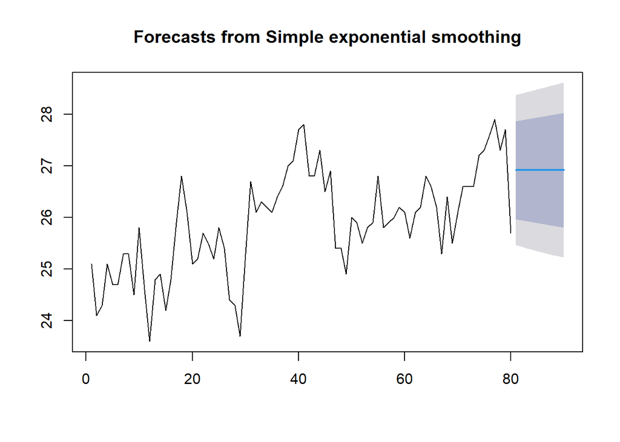

```r
#Cara 1 (fungsi ses)
ses.1 <- ses(train.ts, h = 10, alpha = 0.2)
plot(ses.1)
```

```r
ses.1
```

```
##    Point Forecast    Lo 80    Hi 80    Lo 95    Hi 95
## 81       26.91607 25.96653 27.86560 25.46388 28.36825
## 82       26.91607 25.94773 27.88440 25.43512 28.39701
## 83       26.91607 25.92928 27.90285 25.40691 28.42522
## 84       26.91607 25.91117 27.92096 25.37922 28.45291
## 85       26.91607 25.89339 27.93874 25.35201 28.48012
## 86       26.91607 25.87590 27.95623 25.32528 28.50686
## 87       26.91607 25.85871 27.97342 25.29898 28.53315
## 88       26.91607 25.84179 27.99034 25.27311 28.55903
## 89       26.91607 25.82514 28.00700 25.24763 28.58450
## 90       26.91607 25.80873 28.02340 25.22254 28.60959
```

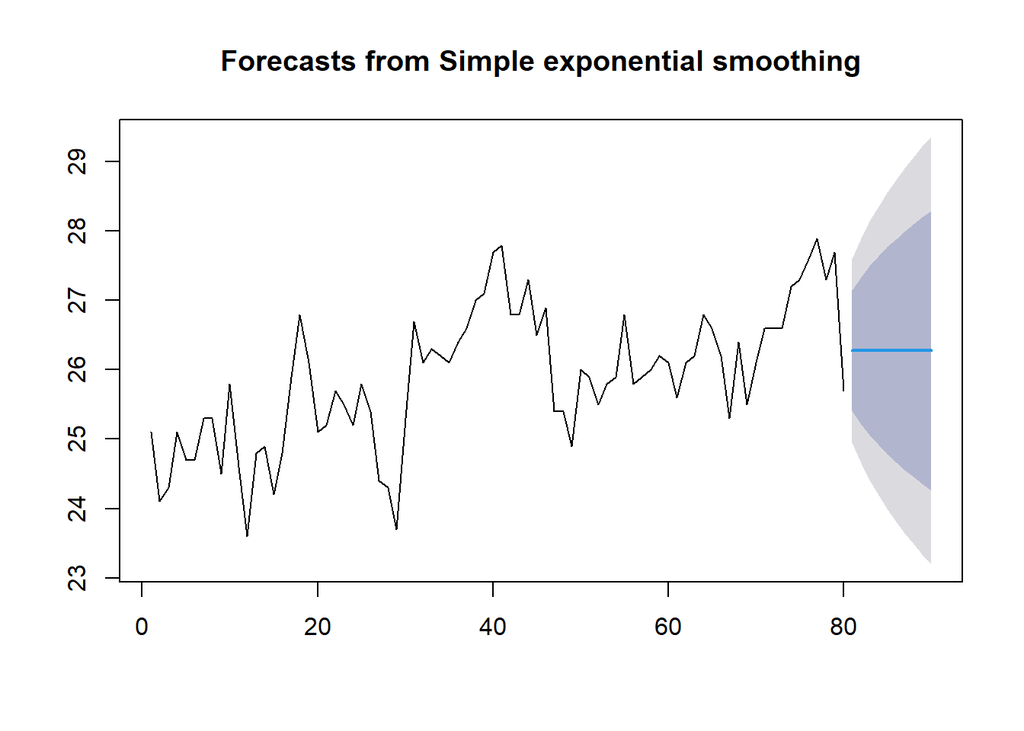

```r
ses.2<- ses(train.ts, h = 10, alpha = 0.7)
plot(ses.2)
```

```r
ses.2
```

```
##    Point Forecast    Lo 80    Hi 80    Lo 95    Hi 95
## 81       26.27683 25.40915 27.14451 24.94983 27.60384
## 82       26.27683 25.21769 27.33597 24.65702 27.89665
## 83       26.27683 25.05590 27.49777 24.40957 28.14409
## 84       26.27683 24.91317 27.64050 24.19128 28.36238
## 85       26.27683 24.78402 27.76965 23.99377 28.55990
## 86       26.27683 24.66519 27.88848 23.81203 28.74163
## 87       26.27683 24.55454 27.99913 23.64281 28.91086
## 88       26.27683 24.45058 28.10309 23.48381 29.06985
## 89       26.27683 24.35222 28.20144 23.33340 29.22027
## 90       26.27683 24.25866 28.29501 23.19030 29.36336
```

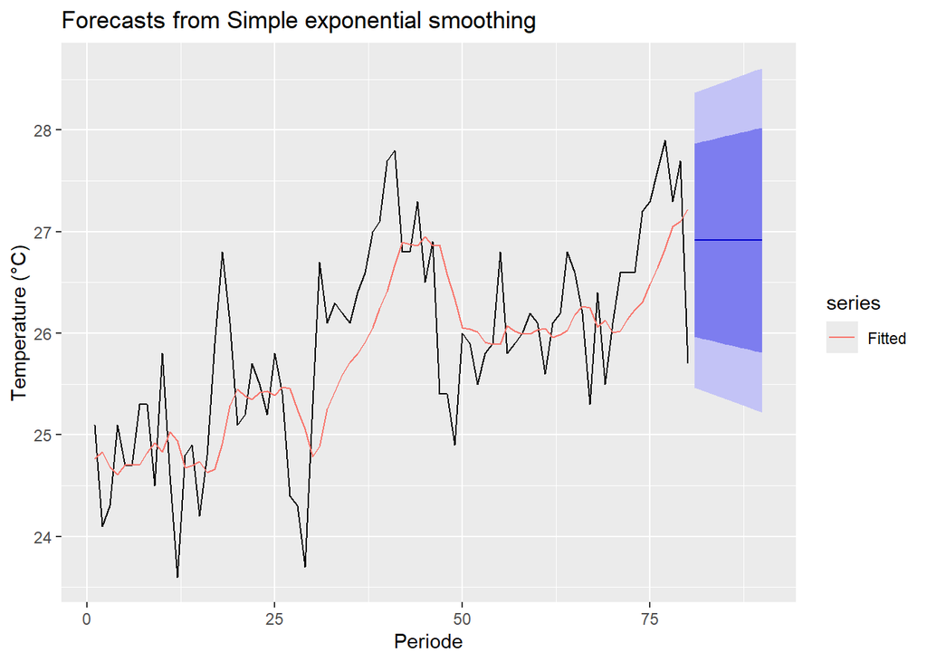

```r
autoplot(ses.1) +
  autolayer(fitted(ses.1), series="Fitted") +
  ylab("Temperature (°C)") + xlab("Periode")
```

Selanjutnya akan digunakan fungsi `HoltWinters()` dengan nilai inisialisasi parameter dan panjang periode peramalan yang sama dengan fungsi `ses()` .

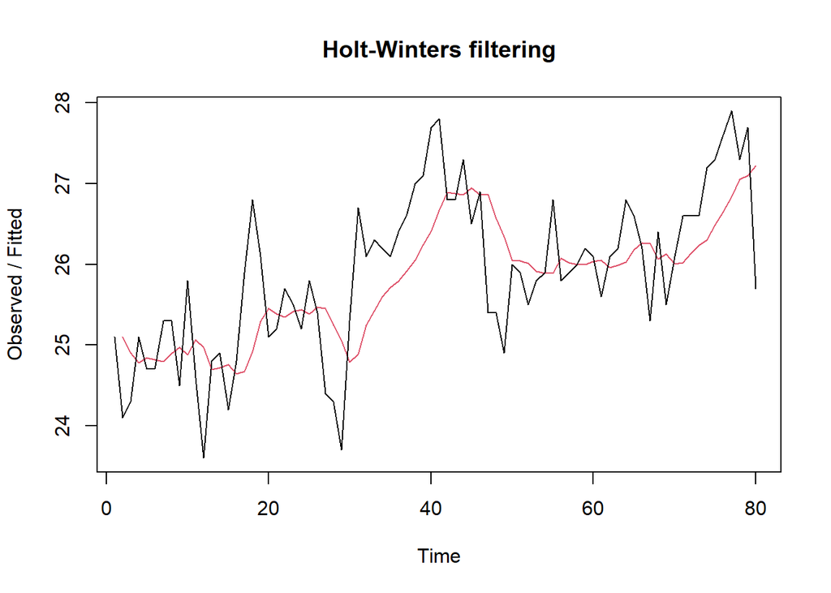

```r
#Cara 2 (fungsi Holtwinter)
ses1<- HoltWinters(train.ts, gamma = FALSE, beta = FALSE, alpha = 0.2)
plot(ses1)
```

```r
#ramalan
ramalan1<- forecast(ses1, h=10)
ramalan1
```

```
##    Point Forecast    Lo 80    Hi 80    Lo 95    Hi 95
## 81       26.91607 25.97463 27.85750 25.47626 28.35587
## 82       26.91607 25.95599 27.87615 25.44775 28.38438
## 83       26.91607 25.93770 27.89444 25.41978 28.41235
## 84       26.91607 25.91974 27.91239 25.39232 28.43981
## 85       26.91607 25.90211 27.93002 25.36535 28.46678
## 86       26.91607 25.88477 27.94736 25.33884 28.49329
## 87       26.91607 25.86773 27.96441 25.31277 28.51936
## 88       26.91607 25.85095 27.98118 25.28712 28.54502
## 89       26.91607 25.83444 27.99769 25.26186 28.57027
## 90       26.91607 25.81817 28.01396 25.23698 28.59515
```

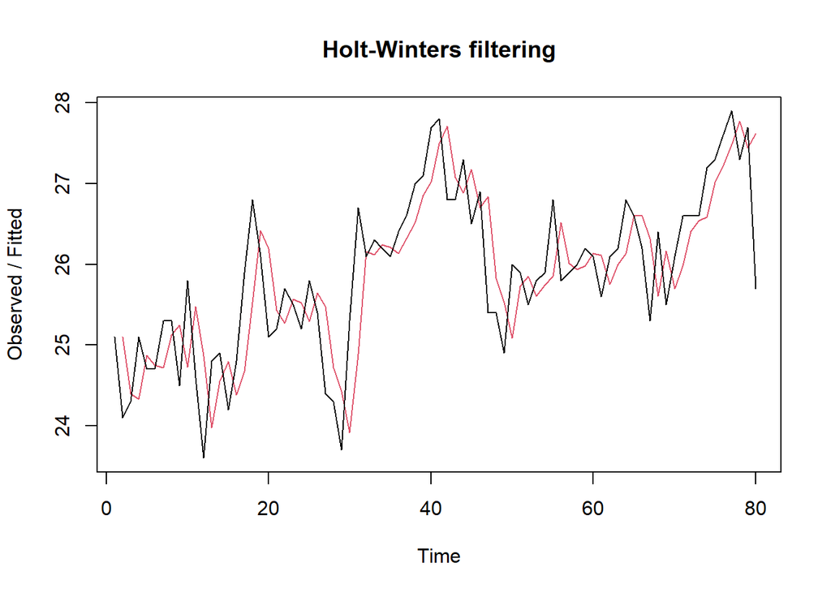

```r
ses2<- HoltWinters(train.ts, gamma = FALSE, beta = FALSE, alpha = 0.7)
plot(ses2)
```

```r
#ramalan
ramalan2<- forecast(ses2, h=10)
ramalan2
```

```
##    Point Forecast    Lo 80    Hi 80    Lo 95    Hi 95
## 81       26.27683 25.40866 27.14500 24.94908 27.60459
## 82       26.27683 25.21710 27.33657 24.65611 27.89756
## 83       26.27683 25.05521 27.49846 24.40852 28.14515
## 84       26.27683 24.91240 27.64127 24.19011 28.36356
## 85       26.27683 24.78318 27.77049 23.99248 28.56118
## 86       26.27683 24.66428 27.88939 23.81064 28.74302
## 87       26.27683 24.55356 28.00010 23.64132 28.91235
## 88       26.27683 24.44955 28.10412 23.48224 29.07143
## 89       26.27683 24.35114 28.20253 23.33174 29.22193
## 90       26.27683 24.25752 28.29615 23.18856 29.36511
```

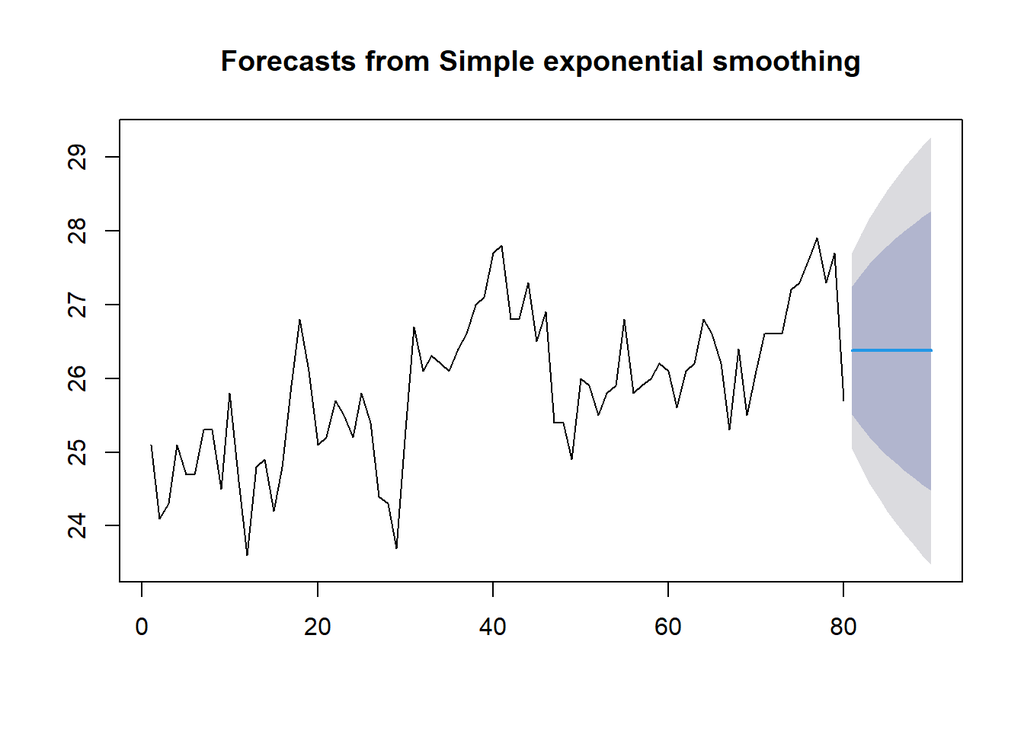

```r
#SES
ses.opt <- ses(train.ts, h = 10, alpha = NULL)
plot(ses.opt)
```

```r
ses.opt
```

```
##    Point Forecast    Lo 80    Hi 80    Lo 95    Hi 95
## 81       26.37426 25.50728 27.24125 25.04832 27.70020
## 82       26.37426 25.34129 27.40724 24.79447 27.95406
## 83       26.37426 25.19851 27.55002 24.57610 28.17243
## 84       26.37426 25.07128 27.67725 24.38152 28.36701
## 85       26.37426 24.95541 27.79311 24.20432 28.54421
## 86       26.37426 24.84832 27.90021 24.04054 28.70799
## 87       26.37426 24.74827 28.00026 23.88752 28.86101
## 88       26.37426 24.65402 28.09451 23.74338 29.00515
## 89       26.37426 24.56468 28.18385 23.60674 29.14179
## 90       26.37426 24.47954 28.26899 23.47654 29.27199
```

```r
#Lamda Optimum Holt Winter
HWopt<- HoltWinters(train.ts, gamma = FALSE, beta = FALSE,alpha = NULL)
HWopt
```

```
## Holt-Winters exponential smoothing without trend and without seasonal component.
##
## Call:
## HoltWinters(x = train.ts, alpha = NULL, beta = FALSE, gamma = FALSE)
##
## Smoothing parameters:
##  alpha: 0.6592158
##  beta : FALSE
##  gamma: FALSE
##
## Coefficients:
##       [,1]
## a 26.35295
```

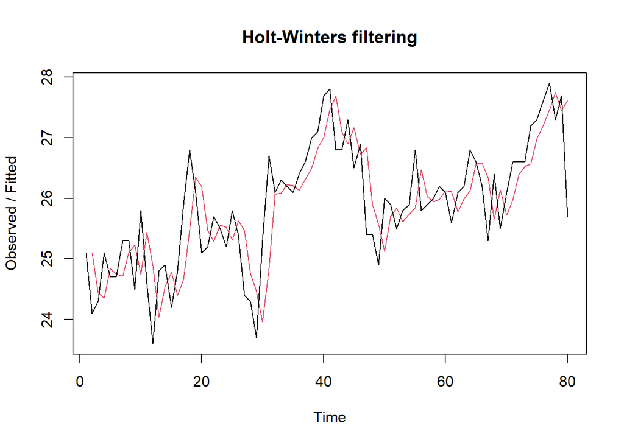

```r
plot(HWopt)
```

```r
#ramalan
ramalanopt<- forecast(HWopt, h=10)
ramalanopt
```

```
##    Point Forecast    Lo 80    Hi 80    Lo 95    Hi 95
## 81       26.35295 25.48532 27.22057 25.02603 27.67986
## 82       26.35295 25.31376 27.39213 24.76365 27.94224
## 83       26.35295 25.16676 27.53913 24.53884 28.16705
## 84       26.35295 25.03607 27.66982 24.33896 28.36693
## 85       26.35295 24.91723 27.78866 24.15721 28.54869
## 86       26.35295 24.80750 27.89839 23.98939 28.71651
## 87       26.35295 24.70506 28.00084 23.83272 28.87318
## 88       26.35295 24.60862 28.09727 23.68523 29.02066
## 89       26.35295 24.51724 28.18865 23.54548 29.16041
## 90       26.35295 24.43021 28.27568 23.41237 29.29352
```

Setelah dilakukan peramalan, akan dilakukan perhitungan keakuratan hasil peramalan. Perhitungan akurasi ini dilakukan baik pada data latih dan data uji.

#### Akurasi Data Latih

```r
# SES dengan alpha = 0.2
SSE1<-ses1$SSE
MSE1<-ses1$SSE/length(train.ts)
RMSE1<-sqrt(MSE1)

akurasi1 <- matrix(c(SSE1,MSE1,RMSE1))
row.names(akurasi1)<- c("SSE", "MSE", "RMSE")
colnames(akurasi1) <- c("Akurasi lamda=0.2")
akurasi1
```

```
##      Akurasi lamda=0.2
## SSE         43.1361670
## MSE          0.5392021
## RMSE         0.7343038
```

```r
# SES dengan alpha = 0.7
SSE2<-ses2$SSE
MSE2<-ses2$SSE/length(train.ts)
RMSE2<-sqrt(MSE2)

akurasi2 <- matrix(c(SSE2,MSE2,RMSE2))
row.names(akurasi2)<- c("SSE", "MSE", "RMSE")
colnames(akurasi2) <- c("Akurasi lamda=0.7")
akurasi2
```

```
##      Akurasi lamda=0.7
## SSE         35.8316035
## MSE          0.4478950
## RMSE         0.6692496
```

```r
# Cara Manual

# Alpha = 0.2
fitted1 <- ramalan1$fitted
sisaan1 <- ramalan1$residuals
head(sisaan1)
```

```
## Time Series:
## Start = 1
## End = 6
## Frequency = 1
## [1]      NA -1.0000 -0.6000  0.3200 -0.1440 -0.1152
```

```r
resid1 <- train.ts - ramalan1$fitted
head(resid1)
```

```
## Time Series:
## Start = 1
## End = 6
## Frequency = 1
## [1]      NA -1.0000 -0.6000  0.3200 -0.1440 -0.1152
```

```r
SSE.1 <- sum(sisaan1[2:length(train.ts)]^2)
SSE.1
```

```
## [1] 43.13617
```

```r
MSE.1 <- SSE.1 / length(train.ts)
MSE.1
```

```
## [1] 0.5392021
```

```r
MAPE.1 <- sum(abs(sisaan1[2:length(train.ts)] /
                    train.ts[2:length(train.ts)]) * 100) / length(train.ts)
MAPE.1
```

```
## [1] 2.220859
```

```r
akurasi.1 <- matrix(c(SSE.1, MSE.1, MAPE.1))
row.names(akurasi.1) <- c("SSE", "MSE", "MAPE")
colnames(akurasi.1) <- c("Akurasi lamda=0.2")
akurasi.1
```

```
##      Akurasi lamda=0.2
## SSE         43.1361670
## MSE          0.5392021
## MAPE         2.2208595
```

```r
# Alpha = 0.7
fitted2 <- ramalan2$fitted
sisaan2 <- ramalan2$residuals
head(sisaan2)
```

```
## Time Series:
## Start = 1
## End = 6
## Frequency = 1
## [1]      NA -1.0000 -0.1000  0.7700 -0.1690 -0.0507
```

```r
resid2 <- train.ts - ramalan2$fitted
head(resid2)
```

```
## Time Series:
## Start = 1
## End = 6
## Frequency = 1
## [1]      NA -1.0000 -0.1000  0.7700 -0.1690 -0.0507
```

```r
SSE.2 <- sum(sisaan2[2:length(train.ts)]^2)
SSE.2
```

```
## [1] 35.8316
```

```r
MSE.2 <- SSE.2 / length(train.ts)
MSE.2
```

```
## [1] 0.447895
```

```r
MAPE.2 <- sum(abs(sisaan2[2:length(train.ts)] /
                    train.ts[2:length(train.ts)]) * 100) / length(train.ts)
MAPE.2
```

```
## [1] 2.034839
```

```r
akurasi.2 <- matrix(c(SSE.2, MSE.2, MAPE.2))
row.names(akurasi.2) <- c("SSE", "MSE", "MAPE")
colnames(akurasi.2) <- c("Akurasi lamda=0.7")
akurasi.2
```

```
##      Akurasi lamda=0.7
## SSE          35.831604
## MSE           0.447895
## MAPE          2.034839
```

Berdasarkan nilai SSE, MSE, dan RMSE di antara kedua parameter, nilai parameter λ = 0,7 menghasilkan akurasi yang lebih baik dibanding λ = 0,2. Hal ini dilihat dari nilai masing-masing ukuran akurasi yang lebih kecil. Berdasarkan nilai MAPE-nya, hasil ini dapat dikategorikan sebagai peramalan sangat baik.

#### Akurasi Data Uji

Akurasi data uji dapat dihitung dengan cara yang hampir sama dengan perhitungan akurasi data latih.

```r
# jumlah observasi uji
n_test <- nrow(testing)

# error (ramalan - aktual)
e1   <- as.numeric(ramalan1$mean)[1:n_test] -
        as.numeric(testing$`temperature_2m_mean (°C)`)

e2   <- as.numeric(ramalan2$mean)[1:n_test] -
        as.numeric(testing$`temperature_2m_mean (°C)`)

eopt <- as.numeric(ramalanopt$mean)[1:n_test] -
        as.numeric(testing$`temperature_2m_mean (°C)`)

# SSE / MSE / RMSE untuk masing-masing model
SSEtesting1  <- sum(e1^2, na.rm = TRUE)
MSEtesting1  <- mean(e1^2, na.rm = TRUE)
RMSEtesting1 <- sqrt(MSEtesting1)

SSEtesting2  <- sum(e2^2, na.rm = TRUE)
MSEtesting2  <- mean(e2^2, na.rm = TRUE)
RMSEtesting2 <- sqrt(MSEtesting2)

SSEtestingopt  <- sum(eopt^2, na.rm = TRUE)
MSEtestingopt  <- mean(eopt^2, na.rm = TRUE)
RMSEtestingopt <- sqrt(MSEtestingopt)

# Tabel ringkas
akurasitesting_SSE <- matrix(
  c(SSEtesting1, SSEtesting2, SSEtestingopt),
  nrow = 3,
  dimnames = list(c("SSE1", "SSE2", "SSEopt"), "Nilai")
)

akurasitesting_MSE <- matrix(
  c(MSEtesting1, MSEtesting2, MSEtestingopt),
  nrow = 3,
  dimnames = list(c("MSE1", "MSE2", "MSEopt"), "Nilai")
)

akurasitesting_RMSE <- matrix(
  c(RMSEtesting1, RMSEtesting2, RMSEtestingopt),
  nrow = 3,
  dimnames = list(c("RMSE1", "RMSE2", "RMSEopt"), "Nilai")
)

akurasitesting_SSE
```

```
##            Nilai
## SSE1   10.719276
## SSE2    3.988800
## SSEopt  4.361582
```

```r
akurasitesting_MSE
```

```
##            Nilai
## MSE1   1.0719276
## MSE2   0.3988800
## MSEopt 0.4361582
```

```r
akurasitesting_RMSE
```

```
##             Nilai
## RMSE1   1.0353393
## RMSE2   0.6315695
## RMSEopt 0.6604228
```

### Double Exponential Smoothing (DES)

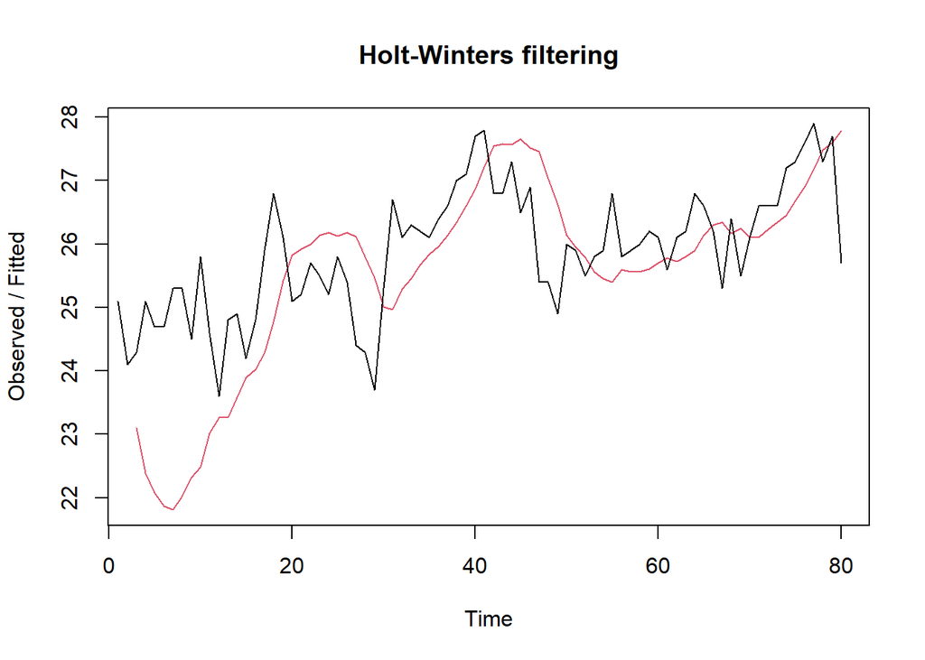

```r
# Lambda = 0.2 dan gamma = 0.2
des.1 <- HoltWinters(train.ts,
                     gamma = FALSE,
                     beta = 0.2,
                     alpha = 0.2)

plot(des.1)
```

```r
# Ramalan
ramalandes1 <- forecast(des.1, h = 10)
ramalandes1
```

```
##    Point Forecast    Lo 80    Hi 80    Lo 95    Hi 95
## 81       27.43894 25.89325 28.98464 25.07501 29.80288
## 82       27.51399 25.92440 29.10358 25.08293 29.94505
## 83       27.58904 25.94159 29.23649 25.06948 30.10860
## 84       27.66409 25.94399 29.38419 25.03342 30.29476
## 85       27.73914 25.93127 29.54700 24.97424 30.50403
## 86       27.81418 25.90352 29.72485 24.89207 30.73630
## 87       27.88923 25.86113 29.91733 24.78752 30.99095
## 88       27.96428 25.80473 30.12383 24.66153 31.26703
## 89       28.03933 25.73505 30.34361 24.51524 31.56342
## 90       28.11438 25.65289 30.57587 24.34985 31.87890
```

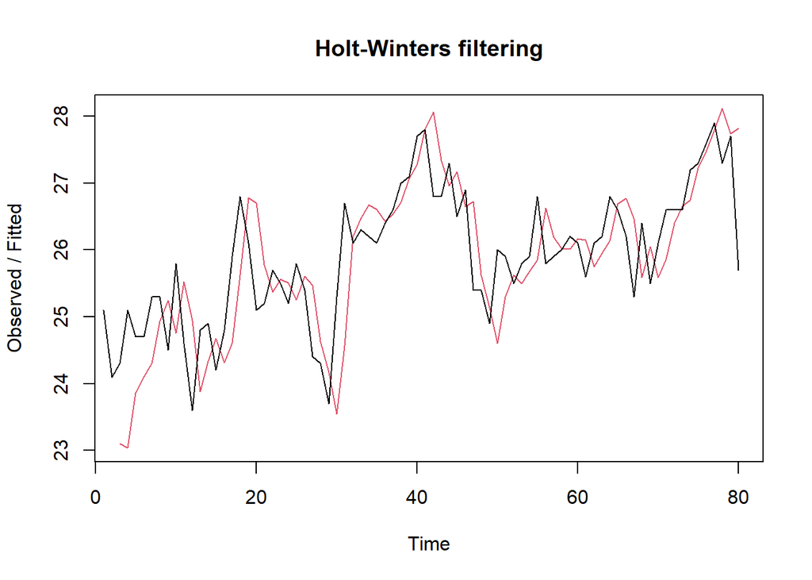

```r
# Lambda = 0.6 dan gamma = 0.3
des.2 <- HoltWinters(train.ts,
                     gamma = FALSE,
                     beta = 0.3,
                     alpha = 0.6)

plot(des.2)
```

```r
# Ramalan
ramalandes2 <- forecast(des.2, h = 10)
ramalandes2
```

```
##    Point Forecast    Lo 80    Hi 80    Lo 95    Hi 95
## 81       26.27082 25.24911 27.29252 24.70826 27.83338
## 82       25.99380 24.69805 27.28955 24.01212 27.97548
## 83       25.71679 24.09167 27.34191 23.23138 28.20219
## 84       25.43977 23.44036 27.43918 22.38194 28.49760
## 85       25.16276 22.75102 27.57450 21.47432 28.85120
## 86       24.88574 22.02826 27.74323 20.51560 29.25589
## 87       24.60873 21.27534 27.94211 19.51076 29.70670
## 88       24.33171 20.49468 28.16875 18.46347 30.19996
## 89       24.05470 19.68811 28.42128 17.37658 30.73281
## 90       23.77768 18.85714 28.69822 16.25237 31.30300
```

Selanjutnya jika ingin membandingkan plot data latih dan data uji adalah sebagai berikut.

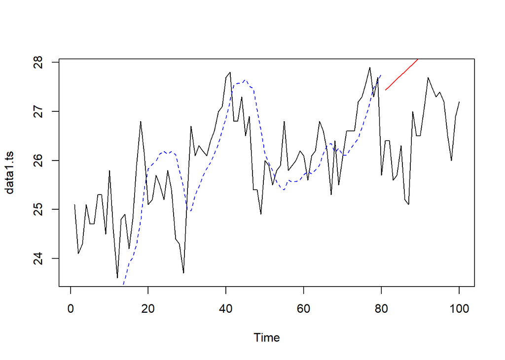

```r
plot(data1.ts)
lines(des.1$fitted[,1], lty=2, col="blue")
lines(ramalandes1$mean, col="red")
```

Untuk mendapatkan nilai parameter optimum dari DES, argumen `alpha` dan `beta` dapat dibuat `NULL` seperti berikut.

```r
#Lamda dan gamma optimum
des.opt<- HoltWinters(train.ts, gamma = FALSE)
des.opt
```

```
## Holt-Winters exponential smoothing with trend and without seasonal component.
##
## Call:
## HoltWinters(x = train.ts, gamma = FALSE)
##
## Smoothing parameters:
##  alpha: 0.8704677
##  beta : 0.1590195
##  gamma: FALSE
##
## Coefficients:
##        [,1]
## a 25.969761
## b -0.177185
```

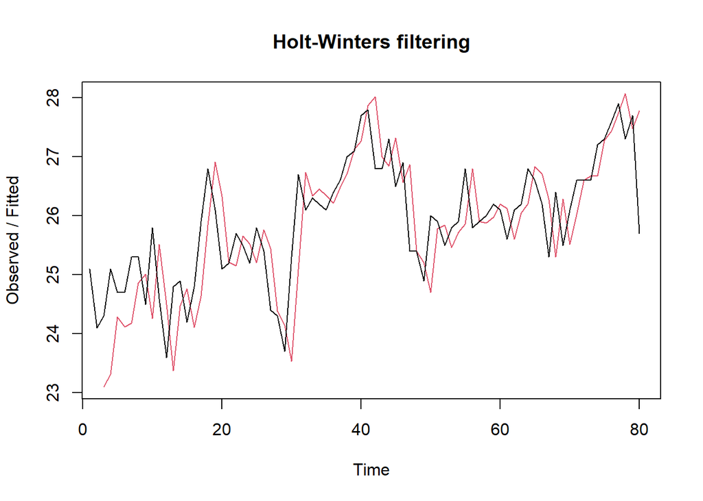

```r
plot(des.opt)
```

```r
#ramalan
ramalandesopt<- forecast(des.opt, h=10)
ramalandesopt
```

```
##    Point Forecast    Lo 80    Hi 80    Lo 95    Hi 95
## 81       25.79258 24.80746 26.77770 24.28596 27.29919
## 82       25.61539 24.21601 27.01477 23.47523 27.75555
## 83       25.43821 23.63940 27.23701 22.68717 28.18924
## 84       25.26102 23.06103 27.46102 21.89642 28.62562
## 85       25.08384 22.47457 27.69310 21.09331 29.07437
## 86       24.90665 21.87716 27.93614 20.27345 29.53985
## 87       24.72947 21.26743 28.19151 19.43473 30.02420
## 88       24.55228 20.64469 28.45987 18.57614 30.52842
## 89       24.37510 20.00869 28.74151 17.69725 31.05294
## 90       24.19791 19.35934 29.03649 16.79795 31.59787
```

Selanjutnya akan dilakukan perhitungan akurasi pada data latih maupun data uji dengan ukuran akurasi SSE, MSE dan MAPE.

#### Akurasi Data Latih

```r
# Akurasi Data Training

ssedes.train1 <- des.1$SSE
msedes.train1 <- ssedes.train1 / length(train.ts)

sisaandes1 <- ramalandes1$residuals
head(sisaandes1)
```

```
## Time Series:
## Start = 1
## End = 6
## Frequency = 1
## [1]       NA       NA 1.200000 2.712000 2.613120 2.829491
```

```r
mapedes.train1 <- sum(
  abs(sisaandes1[3:length(train.ts)] / train.ts[3:length(train.ts)]) * 100
) / length(train.ts)

akurasides.1 <- matrix(c(ssedes.train1, msedes.train1, mapedes.train1))
row.names(akurasides.1) <- c("SSE", "MSE", "MAPE")
colnames(akurasides.1) <- c("Akurasi lamda=0.2 dan gamma=0.2")
akurasides.1
```

```
##      Akurasi lamda=0.2 dan gamma=0.2
## SSE                       121.272955
## MSE                         1.515912
## MAPE                        3.590553
```

```r
# Lambda = 0.6 dan gamma = 0.3

ssedes.train2 <- des.2$SSE
msedes.train2 <- ssedes.train2 / length(train.ts)

sisaandes2 <- ramalandes2$residuals
head(sisaandes2)
```

```
## Time Series:
## Start = 1
## End = 6
## Frequency = 1
## [1]        NA        NA 1.2000000 2.0640000 0.8380800 0.5968576
```

```r
mapedes.train2 <- sum(
  abs(sisaandes2[3:length(train.ts)] / train.ts[3:length(train.ts)]) * 100
) / length(train.ts)

akurasides.2 <- matrix(c(ssedes.train2, msedes.train2, mapedes.train2))
row.names(akurasides.2) <- c("SSE", "MSE", "MAPE")
colnames(akurasides.2) <- c("Akurasi lamda=0.6 dan gamma=0.3")
akurasides.2
```

```
##      Akurasi lamda=0.6 dan gamma=0.3
## SSE                       49.1473225
## MSE                        0.6143415
## MAPE                       2.3072559
```

Hasil akurasi dari data latih didapatkan skenario 2 dengan λ = 0,6 dan γ = 0,3 memiliki hasil yang lebih baik. Skenario 2 menghasilkan nilai SSE sebesar 49,1473, MSE sebesar 0,6143, dan MAPE sebesar 2,3073. Berdasarkan nilai MAPE-nya, skenario 2 dapat dikategorikan sebagai peramalan sangat baik.

#### Akurasi Data Uji

```r
# Ramalan DES skenario 1
ramalandes1 <- forecast(des.1, h = 20)
ramalandes1
```

```
##     Point Forecast    Lo 80    Hi 80    Lo 95    Hi 95
##  81       27.43894 25.89325 28.98464 25.07501 29.80288
##  82       27.51399 25.92440 29.10358 25.08293 29.94505
##  83       27.58904 25.94159 29.23649 25.06948 30.10860
##  84       27.66409 25.94399 29.38419 25.03342 30.29476
##  85       27.73914 25.93127 29.54700 24.97424 30.50403
##  86       27.81418 25.90352 29.72485 24.89207 30.73630
##  87       27.88923 25.86113 29.91733 24.78752 30.99095
##  88       27.96428 25.80473 30.12383 24.66153 31.26703
##  89       28.03933 25.73505 30.34361 24.51524 31.56342
##  90       28.11438 25.65289 30.57587 24.34985 31.87890
##  91       28.18943 25.55902 30.81983 24.16657 32.21228
##  92       28.26447 25.45420 31.07475 23.96653 32.56242
##  93       28.33952 25.33912 31.33992 23.75081 32.92824
##  94       28.41457 25.21442 31.61472 23.52037 33.30877
##  95       28.48962 25.08067 31.89857 23.27608 33.70315
##  96       28.56467 24.93837 32.19096 23.01873 34.11060
##  97       28.63971 24.78799 32.49144 22.74901 34.53042
##  98       28.71476 24.62992 32.79961 22.46753 34.96200
##  99       28.78981 24.46452 33.11510 22.17485 35.40478
## 100       28.86486 24.29211 33.43761 21.87145 35.85827
```

```r
# Ramalan DES skenario 2
ramalandes2 <- forecast(des.2, h = 20)
ramalandes2
```

```
##     Point Forecast     Lo 80    Hi 80     Lo 95    Hi 95
##  81       26.27082 25.249113 27.29252 24.708256 27.83338
##  82       25.99380 24.698050 27.28955 24.012120 27.97548
##  83       25.71679 24.091669 27.34191 23.231383 28.20219
##  84       25.43977 23.440364 27.43918 22.381941 28.49760
##  85       25.16276 22.751018 27.57450 21.474320 28.85120
##  86       24.88574 22.028259 27.74323 20.515599 29.25589
##  87       24.60873 21.275344 27.94211 19.510756 29.70670
##  88       24.33171 20.494676 28.16875 18.463472 30.19996
##  89       24.05470 19.688115 28.42128 17.376585 30.73281
##  90       23.77768 18.857145 28.69822 16.252369 31.30300
##  91       23.50067 18.002993 28.99835 15.092699 31.90864
##  92       23.22365 17.126695 29.32061 13.899160 32.54815
##  93       22.94664 16.229144 29.66414 12.673116 33.22016
##  94       22.66963 15.311118 30.02813 11.415760 33.92349
##  95       22.39261 14.373312 30.41191 10.128152 34.65707
##  96       22.11560 13.416344 30.81485  8.811238 35.41995
##  97       21.83858 12.440775 31.23639  7.465877 36.21129
##  98       21.56157 11.447115 31.67602  6.092847 37.03029
##  99       21.28455 10.435831 32.13327  4.692865 37.87624
## 100       21.00754  9.407355 32.60772  3.266589 38.74848
```

```r
# Ramalan DES optimal
ramalandesopt <- forecast(des.opt, h = 20)
ramalandesopt
```

```
##     Point Forecast    Lo 80    Hi 80     Lo 95    Hi 95
##  81       25.79258 24.80746 26.77770 24.285964 27.29919
##  82       25.61539 24.21601 27.01477 23.475229 27.75555
##  83       25.43821 23.63940 27.23701 22.687173 28.18924
##  84       25.26102 23.06103 27.46102 21.896421 28.62562
##  85       25.08384 22.47457 27.69310 21.093306 29.07437
##  86       24.90665 21.87716 27.93614 20.273449 29.53985
##  87       24.72947 21.26743 28.19151 19.434733 30.02420
##  88       24.55228 20.64469 28.45987 18.576142 30.52842
##  89       24.37510 20.00869 28.74151 17.697248 31.05294
##  90       24.19791 19.35934 29.03649 16.797949 31.59787
##  91       24.02073 18.69670 29.34475 15.878333 32.16312
##  92       23.84354 18.02091 29.66617 14.938597 32.74849
##  93       23.66636 17.33214 30.00058 13.979003 33.35371
##  94       23.48917 16.63057 30.34777 12.999848 33.97849
##  95       23.31199 15.91642 30.70755 12.001449 34.62252
##  96       23.13480 15.18990 31.07970 10.984127 35.28548
##  97       22.95762 14.45122 31.46401  9.948205 35.96703
##  98       22.78043 13.70058 31.86028  8.894003 36.66686
##  99       22.60325 12.93820 32.26829  7.821831 37.38466
## 100       22.42606 12.16426 32.68786  6.731993 38.12013
```

```r
# Akurasi Data Testing

selisihdes1 <- ramalandes1$mean - testing$`temperature_2m_mean (°C)`
selisihdes1
```

```
## Time Series:
## Start = 81
## End = 100
## Frequency = 1
##  [1] 1.0389423 1.1139906 1.9890389 1.9640871 1.4391354 2.6141837 2.7892320
##  [8] 0.9642803 1.5393286 1.6143769 1.0894252 0.5644734 0.8395217 1.1145700
## [15] 1.0896183 1.3646666 2.1397149 2.7147632 1.8898115 1.6648598
```

```r
SSEtestingdes1 <- sum(selisihdes1^2)
MSEtestingdes1 <- SSEtestingdes1 / length(testing$`temperature_2m_mean (°C)`)
MAPEtestingdes1 <- sum(abs(selisihdes1 / testing$`temperature_2m_mean (°C)`) * 100) /
                   length(testing$`temperature_2m_mean (°C)`)


selisihdes2 <- ramalandes2$mean - testing$`temperature_2m_mean (°C)`
selisihdes2
```

```
## Time Series:
## Start = 81
## End = 100
## Frequency = 1
##  [1] -0.1291831 -0.4061978  0.1167874 -0.2602273 -1.1372420 -0.3142568
##  [7] -0.4912715 -2.6682863 -2.4453010 -2.7223157 -3.5993305 -4.4763452
## [13] -4.5533599 -4.6303747 -5.0073894 -5.0844041 -4.6614189 -4.4384336
## [19] -5.6154483 -6.1924631
```

```r
SSEtestingdes2 <- sum(selisihdes2^2)
MSEtestingdes2 <- SSEtestingdes2 / length(testing$`temperature_2m_mean (°C)`)
MAPEtestingdes2 <- sum(abs(selisihdes2 / testing$`temperature_2m_mean (°C)`) * 100) /
                   length(testing$`temperature_2m_mean (°C)`)


selisihdesopt <- ramalandesopt$mean - testing$`temperature_2m_mean (°C)`
selisihdesopt
```

```
## Time Series:
## Start = 81
## End = 100
## Frequency = 1
##  [1] -0.6074236 -0.7846086 -0.1617936 -0.4389786 -1.2161636 -0.2933486
##  [7] -0.3705336 -2.4477186 -2.1249036 -2.3020886 -3.0792736 -3.8564586
## [13] -3.8336436 -3.8108286 -4.0880136 -4.0651986 -3.5423836 -3.2195686
## [19] -4.2967536 -4.7739386
```

```r
SSEtestingdesopt <- sum(selisihdesopt^2)
MSEtestingdesopt <- SSEtestingdesopt / length(testing$`temperature_2m_mean (°C)`)
MAPEtestingdesopt <- sum(abs(selisihdesopt / testing$`temperature_2m_mean (°C)`) * 100) /
                     length(testing$`temperature_2m_mean (°C)`)


akurasitestingdes <- matrix(
  c(SSEtestingdes1, MSEtestingdes1, MAPEtestingdes1,
    SSEtestingdes2, MSEtestingdes2, MAPEtestingdes2,
    SSEtestingdesopt, MSEtestingdesopt, MAPEtestingdesopt),
  nrow = 3,
  ncol = 3
)

row.names(akurasitestingdes) <- c("SSE", "MSE", "MAPE")
colnames(akurasitestingdes) <- c("des ske1", "des ske2", "des opt")

akurasitestingdes
```

```
##       des ske1  des ske2    des opt
## SSE  57.518342 259.80651 169.689823
## MSE   2.875917  12.99033   8.484491
## MAPE  5.992330  10.93196   9.148663
```

#### Perbandingan SES dan DES

```r
MSEfull <-
  matrix(c(MSEtesting1,MSEtesting2,MSEtestingopt,MSEtestingdes1,MSEtestingdes2,
           MSEtestingdesopt),nrow=3,ncol=2)
row.names(MSEfull)<- c("ske 1", "ske 2", "ske opt")
colnames(MSEfull) <- c("ses","des")
MSEfull
```

```
##               ses       des
## ske 1   1.0719276  2.875917
## ske 2   0.3988800 12.990326
## ske opt 0.4361582  8.484491
```

Kedua metode dapat dibandingkan menggunakan ukuran akurasi yang sama, yaitu Mean Squared Error (MSE). Hasil perbandingan menunjukkan bahwa metode SES memiliki akurasi yang lebih baik dibandingkan dengan metode DES pada seluruh skenario. Hal ini ditunjukkan oleh nilai MSE metode SES yang lebih kecil daripada metode DES, yaitu pada skenario 1 sebesar 1,0719 dibandingkan 2,8759, pada skenario 2 sebesar 0,3989 dibandingkan 12,9903, dan pada skenario optimal sebesar 0,4362 dibandingkan 8,4845. Dengan demikian, metode SES memberikan hasil peramalan yang lebih akurat dibandingkan metode DES berdasarkan nilai MSE.

## Seasonal Smoothing

### Winter Aditif

#### Pemulusan

```r
train.ts <- ts(
  training$`temperature_2m_mean (°C)`,
  frequency = 7
)

test.ts <- ts(
  testing$`temperature_2m_mean (°C)`,
  frequency = 7
)
```

```r
frequency(train.ts)
```

```
## [1] 7
```

```r
# Pemulusan dengan Winter aditif
winter1 <- HoltWinters(
  train.ts,
  alpha = 0.2,
  beta = 0.1,
  gamma = 0.1,
  seasonal = "additive"
)

winter1$fitted
```

```
## Time Series:
## Start = c(2, 1)
## End = c(12, 3)
## Frequency = 7
##               xhat    level         trend       season
##  2.000000 25.01156 24.84082  0.0044217687  0.166326531
##  2.142857 24.43659 24.90293  0.0101904762 -0.476530612
##  2.285714 25.74644 24.92580  0.0114587755  0.809183673
##  2.428571 24.89111 24.94797  0.0125299537 -0.069387755
##  2.571429 24.67531 24.90228  0.0067077258 -0.233673469
##  2.714286 24.38831 24.69392 -0.0147984967 -0.290816327
##  2.857143 24.84980 24.76146 -0.0065646477  0.094897959
##  3.000000 24.94878 24.76494 -0.0055605613  0.189401361
##  3.142857 24.11763 24.60962 -0.0205361489 -0.471457415
##  3.285714 25.53214 24.72556 -0.0068887205  0.813468386
##  3.428571 24.70004 24.79224  0.0004684806 -0.092676667
##  3.571429 24.93547 25.21270  0.0424677729 -0.319698360
##  3.714286 25.29596 25.48808  0.0657582852 -0.257880930
##  3.857143 25.67540 25.51465  0.0618391807  0.098914305
##  4.000000 25.66323 25.48140  0.0523312088  0.129499010
##  4.142857 25.17729 25.54109  0.0530665130 -0.416867701
##  4.285714 26.56112 25.65870  0.0595207603  0.842897191
##  4.428571 25.55361 25.44600  0.0322984451  0.075320503
##  4.571429 25.33826 25.52757  0.0372261578 -0.226536311
##  4.714286 25.34205 25.57714  0.0384609411 -0.273557348
##  4.857143 25.50770 25.42720  0.0196199697  0.060882417
##  5.000000 25.33318 25.20528 -0.0045340022  0.132440227
##  5.142857 24.44586 24.87411 -0.0371976558 -0.391050712
##  5.285714 25.72163 25.00774 -0.0201148069  0.734007930
##  5.428571 25.27778 25.18330 -0.0005474044  0.095031353
##  5.571429 25.14149 25.34719  0.0158969972 -0.221597178
##  5.714286 25.28494 25.59479  0.0390671492 -0.348921234
##  5.857143 25.83851 25.81687  0.0573684089 -0.035733470
##  6.000000 25.99092 25.92654  0.0625982932  0.001785612
##  6.142857 25.81901 26.07095  0.0707798532 -0.322719316
##  6.285714 27.19661 26.29793  0.0863996026  0.812277540
##  6.428571 26.58828 26.34501  0.0824674730  0.160808960
##  6.571429 26.49360 26.52982  0.0927017915 -0.128916570
##  6.714286 26.70491 26.86380  0.1168297210 -0.275716195
##  6.857143 27.32356 27.19965  0.1387314627 -0.014813933
```

[output cut: 23 more lines]

```
## 10.285714 26.83886 26.29727  0.0214294307  0.520161179
## 10.428571 26.34734 26.19093  0.0086521958  0.147763884
## 10.571429 25.81964 25.99011 -0.0122946902 -0.158179895
## 10.714286 25.94475 26.09389 -0.0006874296 -0.148453347
## 10.857143 25.84224 26.00425 -0.0095824035 -0.152431780
## 11.000000 26.07214 26.04622 -0.0044271659  0.030349495
## 11.142857 25.98232 26.14737  0.0061299420 -0.171178889
## 11.285714 26.76457 26.27703  0.0184835972  0.469052239
## 11.428571 26.34177 26.26260  0.0151922268  0.063976340
## 11.571429 26.37005 26.44944  0.0323568040 -0.111750852
## 11.714286 26.53471 26.66779  0.0509558735 -0.184033242
## 11.857143 26.87225 26.93180  0.0722616594 -0.131810830
## 12.000000 27.37501 27.20961  0.0928166067  0.072577927
## 12.142857 27.25698 27.28743  0.0913164573 -0.121764268
## 12.285714 28.02341 27.46735  0.1001768525  0.455886758
```

```r
xhat1 <- winter1$fitted[,2]


# Winter aditif dengan parameter optimum
winter1.opt <- HoltWinters(
  train.ts,
  alpha = NULL,
  beta = NULL,
  gamma = NULL,
  seasonal = "additive"
)

winter1.opt
```

```
## Holt-Winters exponential smoothing with trend and additive seasonal component.
##
## Call:
## HoltWinters(x = train.ts, alpha = NULL, beta = NULL, gamma = NULL,     seasonal = "additive")
##
## Smoothing parameters:
##  alpha: 0.4859654
##  beta : 0
##  gamma: 0.4230173
##
## Coefficients:
##            [,1]
## a  26.558058301
## b   0.004421769
## s1  0.240099805
## s2  0.265160676
## s3  0.165998722
## s4  0.043717177
## s5  0.047011441
## s6  0.144273015
## s7 -0.282312118
```

```r
winter1.opt$fitted
```

```
## Time Series:
## Start = c(2, 1)
## End = c(12, 3)
## Frequency = 7
##               xhat    level       trend      season
##  2.000000 25.01156 24.84082 0.004421769  0.16632653
##  2.142857 24.51330 24.98541 0.004421769 -0.47653061
##  2.285714 25.79697 24.98337 0.004421769  0.80918367
##  2.428571 24.92429 24.98926 0.004421769 -0.06938776
##  2.571429 24.60683 24.83609 0.004421769 -0.23367347
##  2.714286 24.06483 24.35122 0.004421769 -0.29081633
##  2.857143 24.81223 24.71291 0.004421769  0.09489796
##  3.000000 24.99345 24.75999 0.004421769  0.22904551
##  3.142857 23.90382 24.37882 0.004421769 -0.47942239
##  3.285714 25.63302 24.81875 0.004421769  0.80984207
##  3.428571 24.81744 24.95292 0.004421769 -0.13990401
##  3.571429 25.47261 25.92080 0.004421769 -0.45260507
##  3.714286 26.10357 26.23011 0.004421769 -0.13095616
##  3.857143 25.86523 25.74683 0.004421769  0.11398283
##  4.000000 25.48890 25.42797 0.004421769  0.05651266
##  4.142857 25.25485 25.53498 0.004421769 -0.28455127
##  4.285714 26.53085 25.65853 0.004421769  0.86789636
##  4.428571 25.31182 25.01621 0.004421769  0.29119539
##  4.571429 24.94610 25.25787 0.004421769 -0.31618299
##  4.714286 25.13811 25.48287 0.004421769 -0.34917861
##  4.857143 25.10234 25.12859 0.004421769 -0.03066888
##  5.000000 24.84994 24.74310 0.004421769  0.10241457
##  5.142857 23.96187 24.18869 0.004421769 -0.23124387
##  5.285714 25.42633 24.84340 0.004421769  0.57850850
##  5.428571 25.86855 25.46678 0.004421769  0.39734687
##  5.571429 25.37062 25.58368 0.004421769 -0.21748546
##  5.714286 25.53449 26.03975 0.004421769 -0.50967692
##  5.857143 26.16687 26.36758 0.004421769 -0.20513511
##  6.000000 26.19630 26.33951 0.004421769 -0.14763430
##  6.142857 26.50707 26.44292 0.004421769  0.05972621
##  6.285714 27.35239 26.49251 0.004421769  0.85546238
##  6.428571 26.77777 26.32568 0.004421769  0.44767472
##  6.571429 26.47572 26.48669 0.004421769 -0.01539507
##  6.714286 26.72553 27.08607 0.004421769 -0.36496580
##  6.857143 27.39740 27.61265 0.004421769 -0.21967589
```

[output cut: 23 more lines]

```
## 10.285714 26.83443 26.56232 0.004421769  0.26768609
## 10.428571 26.65648 26.25843 0.004421769  0.39362410
## 10.571429 25.63333 25.60365 0.004421769  0.02525234
## 10.714286 26.15637 25.98065 0.004421769  0.17129580
## 10.857143 25.39212 25.66610 0.004421769 -0.27840247
## 11.000000 26.05190 26.01453 0.004421769  0.03294667
## 11.142857 26.33286 26.28531 0.004421769  0.04313316
## 11.285714 26.55370 26.41955 0.004421769  0.12973152
## 11.428571 26.54956 26.44647 0.004421769  0.09866358
## 11.571429 26.96337 26.76699 0.004421769  0.19196179
## 11.714286 26.96799 26.93500 0.004421769  0.02857127
## 11.857143 27.12650 27.24655 0.004421769 -0.12447713
## 12.000000 27.78342 27.62687 0.004421769  0.15212940
## 12.142857 27.50201 27.39637 0.004421769  0.10122070
## 12.285714 27.64123 27.49700 0.004421769  0.13979861
```

```r
xhat1.opt <- winter1.opt$fitted[,2]
```

#### Plot Deret Waktu

```r
# Ramalan Winter aditif
forecast1 <- forecast(winter1, h = 20)
forecast1
```

```
##          Point Forecast    Lo 80    Hi 80    Lo 95    Hi 95
## 12.42857       27.28919 26.18270 28.39567 25.59697 28.98141
## 12.57143       27.17291 26.03996 28.30585 25.44022 28.90559
## 12.71429       27.16516 26.00151 28.32881 25.38551 28.94481
## 12.85714       27.26809 26.06940 28.46677 25.43486 29.10132
## 13.00000       27.43796 26.19989 28.67604 25.54449 29.33144
## 13.14286       27.33877 26.05697 28.62057 25.37842 29.29912
## 13.28571       27.74882 26.41901 29.07862 25.71505 29.78258
## 13.42857       27.66515 26.25648 29.07382 25.51077 29.81952
## 13.57143       27.54887 26.08496 29.01277 25.31001 29.78772
## 13.71429       27.54112 26.01803 29.06421 25.21175 29.87049
## 13.85714       27.64405 26.05795 29.23014 25.21832 30.06977
## 14.00000       27.81392 26.16115 29.46670 25.28622 30.34163
## 14.14286       27.71473 25.99174 29.43772 25.07965 30.34982
## 14.28571       28.12478 26.32818 29.92137 25.37712 30.87243
## 14.42857       28.04111 26.14066 29.94155 25.13462 30.94759
## 14.57143       27.92483 25.94549 29.90416 24.89769 30.95196
## 14.71429       27.91708 25.85581 29.97835 24.76464 31.06952
## 14.85714       28.02001 25.87389 30.16613 24.73780 31.30221
## 15.00000       28.18988 25.95610 30.42366 24.77361 31.60616
## 15.14286       28.09069 25.76655 30.41483 24.53623 31.64516
```

```r
forecast1.opt <- forecast(winter1.opt, h = 20)
forecast1.opt
```

```
##          Point Forecast    Lo 80    Hi 80    Lo 95    Hi 95
## 12.42857       26.80258 25.83975 27.76541 25.33006 28.27510
## 12.57143       26.83206 25.76156 27.90256 25.19487 28.46925
## 12.71429       26.73732 25.56903 27.90562 24.95057 28.52407
## 12.85714       26.61946 25.36096 27.87797 24.69474 28.54418
## 13.00000       26.62718 25.28450 27.96985 24.57374 28.68062
## 13.14286       26.72886 25.30699 28.15073 24.55430 28.90342
## 13.28571       26.30670 24.80982 27.80357 24.01742 28.59597
## 13.42857       26.83353 25.19057 28.47650 24.32084 29.34623
## 13.57143       26.86301 25.15472 28.57131 24.25041 29.47562
## 13.71429       26.76827 24.99706 28.53949 24.05944 29.47711
## 13.85714       26.65041 24.81844 28.48239 23.84865 29.45218
## 14.00000       26.65813 24.76735 28.54891 23.76643 29.54983
## 14.14286       26.75981 24.81200 28.70763 23.78089 29.73874
## 14.28571       26.33765 24.33442 28.34088 23.27398 29.40132
## 14.42857       26.86448 24.74987 28.97910 23.63045 30.09851
## 14.57143       26.89397 24.72820 29.05973 23.58171 30.20622
## 14.71429       26.79923 24.58349 29.01496 23.41055 30.18790
## 14.85714       26.68137 24.41677 28.94597 23.21796 30.14477
## 15.00000       26.68908 24.37665 29.00152 23.15252 30.22564
## 15.14286       26.79077 24.43147 29.15006 23.18254 30.39900
```

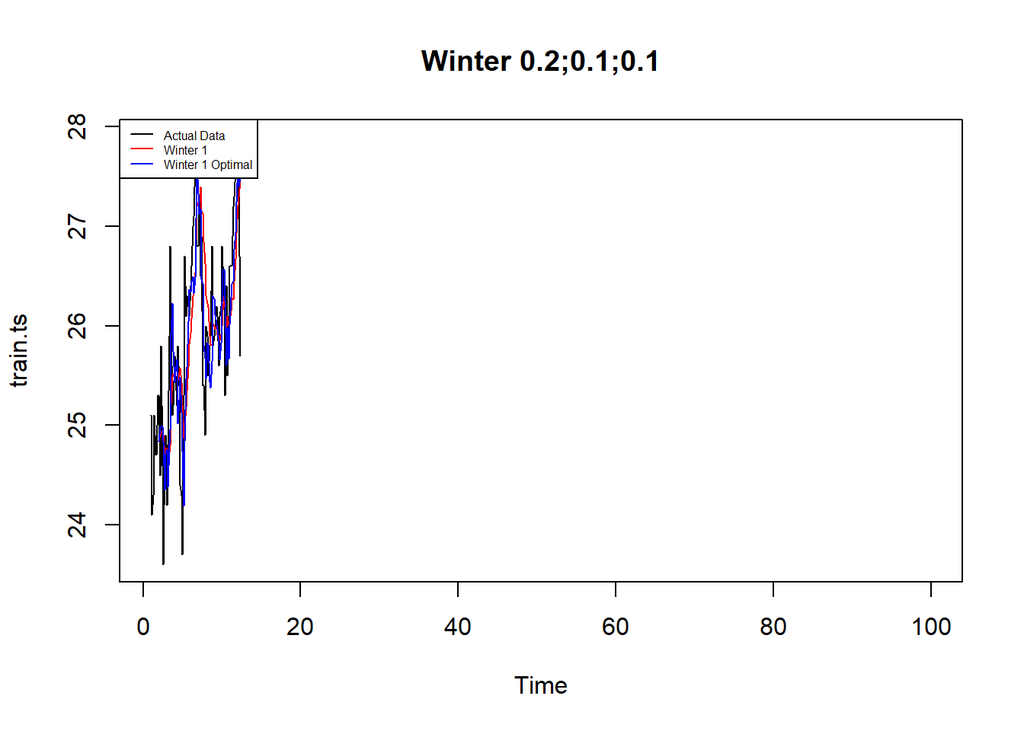

```r
# Plot time series
plot(train.ts,
     main = "Winter 0.2;0.1;0.1",
     type = "l",
     col = "black",
     xlim = c(1, 100),
     pch = 12)

lines(xhat1, type = "l", col = "red")
lines(xhat1.opt, type = "l", col = "blue")

lines(forecast1$pred, type = "l", col = "red")
lines(forecast1.opt$pred, type = "l", col = "blue")

legend("topleft",
       c("Actual Data",
         "Winter 1",
         "Winter 1 Optimal"),
       cex = 0.5,
       col = c("black", "red", "blue"),
       lty = 1)
```

#### Akurasi Data Latih

```r
# Akurasi data training
SSE1 <- winter1$SSE
MSE1 <- winter1$SSE / length(train.ts)
RMSE1 <- sqrt(MSE1)

akurasi1 <- matrix(c(SSE1, MSE1, RMSE1))
row.names(akurasi1) <- c("SSE", "MSE", "RMSE")
colnames(akurasi1) <- c("Akurasi")
akurasi1
```

```
##         Akurasi
## SSE  53.7554261
## MSE   0.6719428
## RMSE  0.8197212
```

```r
SSE1.opt <- winter1.opt$SSE
MSE1.opt <- winter1.opt$SSE / length(train.ts)
RMSE1.opt <- sqrt(MSE1.opt)

akurasi1.opt <- matrix(c(SSE1.opt, MSE1.opt, RMSE1.opt))
row.names(akurasi1.opt) <- c("SSE", "MSE", "RMSE")
colnames(akurasi1.opt) <- c("Akurasi")
akurasi1.opt
```

```
##         Akurasi
## SSE  40.7533809
## MSE   0.5094173
## RMSE  0.7137347
```

```r
akurasi1.train <- data.frame(
  Model_Winter = c("Winter 1", "Winter1 optimal"),
  Nilai_SSE = c(SSE1, SSE1.opt),
  Nilai_MSE = c(MSE1, MSE1.opt),
  Nilai_RMSE = c(RMSE1, RMSE1.opt)
)

akurasi1.train
```

```
##      Model_Winter Nilai_SSE Nilai_MSE Nilai_RMSE
## 1        Winter 1  53.75543 0.6719428  0.8197212
## 2 Winter1 optimal  40.75338 0.5094173  0.7137347
```

#### Akurasi Data Uji

```r
# Akurasi Data Testing

forecast1_test <- as.numeric(forecast1$mean)
forecast1_opt_test <- as.numeric(forecast1.opt$mean)

aktual_test <- as.numeric(test.ts)

selisih1 <- forecast1_test - aktual_test
SSEtesting1 <- sum(selisih1^2)
MSEtesting1 <- SSEtesting1 / length(test.ts)


selisih1.opt <- forecast1_opt_test - aktual_test
SSEtesting1.opt <- sum(selisih1.opt^2)
MSEtesting1.opt <- SSEtesting1.opt / length(test.ts)


akurasi_testing <- data.frame(
  Model = c("Model1", "Model Optimum"),
  SSE = c(SSEtesting1, SSEtesting1.opt),
  MSE = c(MSEtesting1, MSEtesting1.opt)
)

akurasi_testing
```

```
##           Model      SSE       MSE
## 1        Model1 32.32605 1.6163027
## 2 Model Optimum 10.52751 0.5263754
```

```r
akurasi_testing <- data.frame(
  Model = c("Model1", "Model Optimum"),
  SSE   = c(SSEtesting1, SSEtesting1.opt),
  MSE   = c(MSEtesting1, MSEtesting1.opt)
)

akurasi_testing
```

```
##           Model      SSE       MSE
## 1        Model1 32.32605 1.6163027
## 2 Model Optimum 10.52751 0.5263754
```

### Winter Multiplikatif

Model multiplikatif digunakan cocok digunakan jika plot data asli menunjukkan fluktuasi musiman yang bervariasi.

#### Pemulusan

```r
# Pemulusan dengan Winter Multiplikatif
winter2 <- HoltWinters(
  train.ts,
  alpha = 0.2,
  beta = 0.1,
  gamma = 0.3,
  seasonal = "multiplicative"
)

winter2$fitted
```

```
## Time Series:
## Start = c(2, 1)
## End = c(12, 3)
## Frequency = 7
##               xhat    level         trend    season
##  2.000000 25.00936 24.84082  0.0044217687 1.0066059
##  2.142857 24.43848 24.90298  0.0101963403 0.9809460
##  2.285714 25.74519 24.92572  0.0114505655 1.0324021
##  2.428571 24.89193 24.94779  0.0125123439 0.9972608
##  2.571429 24.67586 24.90176  0.0066576810 0.9906637
##  2.714286 24.38954 24.69121 -0.0150623368 0.9883850
##  2.857143 24.84494 24.75921 -0.0067566287 1.0037365
##  3.000000 24.99066 24.76342 -0.0056595086 1.0094069
##  3.142857 24.12600 24.60111 -0.0213252978 0.9815383
##  3.285714 25.52320 24.71712 -0.0075916655 1.0329294
##  3.428571 24.64458 24.78248 -0.0002958222 0.9944472
##  3.571429 24.75877 25.21568  0.0430533509 0.9802063
##  3.714286 25.40731 25.53240  0.0704196692 0.9923638
##  3.857143 25.71444 25.54088  0.0642262458 1.0042701
##  4.000000 25.59992 25.50266  0.0539811046 1.0016935
##  4.142857 25.32713 25.57662  0.0559793568 0.9880828
##  4.285714 26.66813 25.66759  0.0594784553 1.0365785
##  4.428571 25.85612 25.44380  0.0311520700 1.0149623
##  4.571429 25.31074 25.46390  0.0300462190 0.9928136
##  4.714286 25.27495 25.51193  0.0318444392 0.9894761
##  4.857143 25.36658 25.36692  0.0141593020 0.9994288
##  5.000000 25.22670 25.16764 -0.0071845152 1.0026326
##  5.142857 24.56263 24.85592 -0.0376382449 0.9896992
##  5.285714 25.51155 24.96729 -0.0227373966 1.0227303
##  5.428571 25.54086 25.17696  0.0005033413 1.0144333
##  5.571429 25.13866 25.28770  0.0115270867 0.9936533
##  5.714286 25.08715 25.53298  0.0349021986 0.9811981
##  5.857143 25.57459 25.79471  0.0575855934 0.9892578
##  6.000000 25.71158 25.95852  0.0682079020 0.9878914
##  6.142857 26.16392 26.16610  0.0821449727 0.9967872
##  6.285714 27.32671 26.33574  0.0908947663 1.0340592
##  6.428571 26.97011 26.36345  0.0845757653 1.0197400
##  6.571429 26.68199 26.47350  0.0871232777 1.0045695
##  6.714286 26.64369 26.76330  0.1073908291 0.9915522
##  6.857143 27.07437 27.10392  0.1307140064 0.9941155
```

[output cut: 23 more lines]

```
## 10.285714 26.51948 26.32426  0.0236785254 1.0065104
## 10.428571 26.52404 26.28446  0.0173303533 1.0084500
## 10.571429 25.93314 26.05903 -0.0069452746 0.9954343
## 10.714286 26.24616 26.14589  0.0024347646 1.0037417
## 10.857143 25.72742 25.99965 -0.0124328197 0.9900032
## 11.000000 26.09771 26.06248 -0.0049060320 1.0015402
## 11.142857 26.21346 26.15788  0.0051243755 1.0019285
## 11.285714 26.34734 26.24016  0.0128403125 1.0035933
## 11.428571 26.24692 26.30335  0.0178754539 0.9971768
## 11.571429 26.54193 26.51239  0.0369910404 0.9997197
## 11.714286 26.66902 26.70103  0.0521565948 0.9968540
## 11.857143 26.83346 26.93997  0.0708349084 0.9934341
## 12.000000 27.48580 27.22552  0.0923067658 1.0061487
## 12.142857 27.51906 27.28090  0.0886134424 1.0054640
## 12.285714 27.65992 27.40550  0.0922126238 1.0058987
```

```r
xhat2 <- winter2$fitted[,2]
```

#### Peramalan

```r
winter2.opt <- HoltWinters(
  train.ts,
  seasonal = "multiplicative"
)
```

```r
winter2.opt
```

```
## Holt-Winters exponential smoothing with trend and multiplicative seasonal component.
##
## Call:
## HoltWinters(x = train.ts, seasonal = "multiplicative")
##
## Smoothing parameters:
##  alpha: 0.4891742
##  beta : 0
##  gamma: 0.4302076
##
## Coefficients:
##            [,1]
## a  26.567355632
## b   0.004421769
## s1  1.008598160
## s2  1.009639475
## s3  1.005491671
## s4  1.000784650
## s5  1.001100477
## s6  1.004782403
## s7  0.988721466
```

```r
winter2.opt$fitted
```

```
## Time Series:
## Start = c(2, 1)
## End = c(12, 3)
## Frequency = 7
##               xhat    level       trend    season
##  2.000000 25.00936 24.84082 0.004421769 1.0066059
##  2.142857 24.51472 24.98648 0.004421769 0.9809460
##  2.285714 25.79764 24.98356 0.004421769 1.0324021
##  2.428571 24.92505 24.98910 0.004421769 0.9972608
##  2.571429 24.60659 24.83407 0.004421769 0.9906637
##  2.714286 24.06310 24.34145 0.004421769 0.9883850
##  2.857143 24.80735 24.71058 0.004421769 1.0037365
##  3.000000 24.99148 24.76016 0.004421769 1.0091621
##  3.142857 23.91755 24.38093 0.004421769 0.9808165
##  3.285714 25.63494 24.82546 0.004421769 1.0324229
##  3.428571 24.81973 24.95547 0.004421769 0.9943843
##  3.571429 25.46059 25.93406 0.004421769 0.9815759
##  3.714286 26.12864 26.25714 0.004421769 0.9949386
##  3.857143 25.87767 25.75582 0.004421769 1.0045588
##  4.000000 25.48625 25.43024 0.004421769 1.0020280
##  4.142857 25.25296 25.53902 0.004421769 0.9886281
##  4.285714 26.56231 25.66567 0.004421769 1.0347570
##  4.428571 25.30995 25.02607 0.004421769 1.0111648
##  4.571429 24.94162 25.26756 0.004421769 0.9869275
##  4.714286 25.15068 25.49918 0.004421769 0.9861617
##  4.857143 25.10305 25.13124 0.004421769 0.9987025
##  5.000000 24.84245 24.74232 0.004421769 1.0038674
##  5.142857 23.97050 24.19004 0.004421769 0.9907434
##  5.285714 25.42187 24.85089 0.004421769 1.0227942
##  5.428571 25.86397 25.46661 0.004421769 1.0154269
##  5.571429 25.35573 25.58474 0.004421769 0.9908780
##  5.714286 25.52806 26.05532 0.004421769 0.9795974
##  5.857143 26.17715 26.39529 0.004421769 0.9915698
##  6.000000 26.19438 26.36165 0.004421769 0.9934885
##  6.142857 26.53792 26.46731 0.004421769 1.0025004
##  6.285714 27.40299 26.50202 0.004421769 1.0338236
##  6.428571 26.77958 26.31576 0.004421769 1.0174543
##  6.571429 26.44800 26.47423 0.004421769 0.9988423
##  6.714286 26.69499 27.09181 0.004421769 0.9851918
##  6.857143 27.39845 27.64490 0.004421769 0.9909266
```

[output cut: 23 more lines]

```
## 10.285714 26.85080 26.58064 0.004421769 1.0099954
## 10.428571 26.66915 26.26986 0.004421769 1.0150286
## 10.571429 25.63071 25.61445 0.004421769 1.0004620
## 10.714286 26.15287 25.99501 0.004421769 1.0059012
## 10.857143 25.39432 25.68195 0.004421769 0.9886303
## 11.000000 26.05326 26.03554 0.004421769 1.0005107
## 11.142857 26.34031 26.30728 0.004421769 1.0010877
## 11.285714 26.56336 26.43859 0.004421769 1.0045512
## 11.428571 26.55213 26.46085 0.004421769 1.0032819
## 11.571429 26.97216 26.78116 0.004421769 1.0069656
## 11.714286 26.95774 26.94484 0.004421769 1.0003147
## 11.857143 27.12016 27.26334 0.004421769 0.9945868
## 12.000000 27.79618 27.65132 0.004421769 1.0050780
## 12.142857 27.50768 27.41425 0.004421769 1.0032462
## 12.285714 27.65048 27.51245 0.004421769 1.0048555
```

```r
xhat2.opt <- winter2.opt$fitted[,2]
```

```r
#Forecast
forecast2 <- predict(winter2, n.ahead = 20)
forecast2.opt <- predict(winter2.opt, n.ahead = 20)
```

#### Plot Deret Waktu

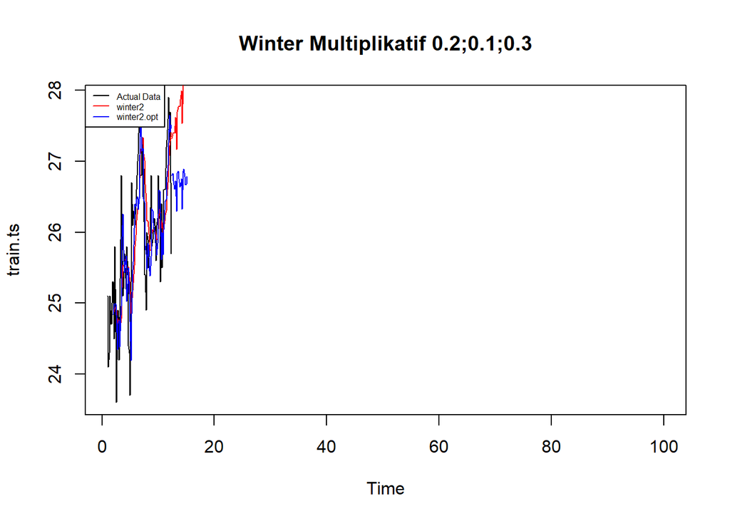

```r
plot(
  train.ts,
  main = "Winter Multiplikatif 0.2;0.1;0.3",
  type = "l",
  col = "black",
  xlim = c(1, 100),
  pch = 12
)

lines(xhat2, type = "l", col = "red")
lines(xhat2.opt, type = "l", col = "blue")
lines(forecast2, type = "l", col = "red")
lines(forecast2.opt, type = "l", col = "blue")

legend(
  "topleft",
  c(
    "Actual Data",
    expression(paste(winter2)),
    expression(paste(winter2.opt))
  ),
  cex = 0.5,
  col = c("black", "red", "blue"),
  lty = 1
)
```

#### Akurasi Data Latih

```r
# Akurasi data training

SSE2 <- winter2$SSE
MSE2 <- winter2$SSE / length(train.ts)
RMSE2 <- sqrt(MSE2)

akurasi2 <- matrix(c(SSE2, MSE2, RMSE2))
row.names(akurasi2) <- c("SSE2", "MSE2", "RMSE2")
colnames(akurasi2) <- c("Akurasi lamda=0.2")
akurasi2
```

```
##       Akurasi lamda=0.2
## SSE2         51.5915886
## MSE2          0.6448949
## RMSE2         0.8030535
```

```r
SSE2.opt <- winter2.opt$SSE
MSE2.opt <- winter2.opt$SSE / length(train.ts)
RMSE2.opt <- sqrt(MSE2.opt)

akurasi2.opt <- matrix(c(SSE2.opt, MSE2.opt, RMSE2.opt))
row.names(akurasi2.opt) <- c("SSE2.opt", "MSE2.opt", "RMSE2.opt")
colnames(akurasi2.opt) <- c("Akurasi")
akurasi2.opt
```

```
##              Akurasi
## SSE2.opt  41.3838369
## MSE2.opt   0.5172980
## RMSE2.opt  0.7192343
```

```r
akurasi2.train <- data.frame(
  Model_Winter = c("Winter Multiplikatif", "Winter Multiplikatif Optimal"),
  Nilai_SSE = c(SSE2, SSE2.opt),
  Nilai_MSE = c(MSE2, MSE2.opt),
  Nilai_RMSE = c(RMSE2, RMSE2.opt)
)

akurasi2.train
```

```
##                   Model_Winter Nilai_SSE Nilai_MSE Nilai_RMSE
## 1         Winter Multiplikatif  51.59159 0.6448949  0.8030535
## 2 Winter Multiplikatif Optimal  41.38384 0.5172980  0.7192343
```

#### Akurasi Data Uji

```r
# Akurasi Data Testing

forecast2_test <- as.numeric(forecast2)
forecast2_opt_test <- as.numeric(forecast2.opt)

aktual_test <- as.numeric(test.ts)

# Winter Multiplikatif
selisih2 <- forecast2_test - aktual_test

SSEtesting2 <- sum(selisih2^2)
MSEtesting2 <- SSEtesting2 / length(test.ts)


# Winter Multiplikatif Optimal
selisih2.opt <- forecast2_opt_test - aktual_test

SSEtesting2.opt <- sum(selisih2.opt^2)
MSEtesting2.opt <- SSEtesting2.opt / length(test.ts)


# Tabel akurasi
akurasi2.testing <- data.frame(
  Model = c("Winter Multiplikatif", "Winter Multiplikatif Optimal"),
  SSE = c(SSEtesting2, SSEtesting2.opt),
  MSE = c(MSEtesting2, MSEtesting2.opt)
)

akurasi2.testing
```

```
##                          Model      SSE       MSE
## 1         Winter Multiplikatif 35.93661 1.7968306
## 2 Winter Multiplikatif Optimal 10.46813 0.5234063
```

# Kesimpulan